# Analysis of minor gland bulk RNA-seq (all samples, blocking on individual)

Johan

01/04/2025

This is a variant of `MinorAnalysis.Rmd` with three changes to the minor parts DE:

1. All samples are kept (no QC-removed samples).
2. The part-vs-Tail_proximal DE is blocked on individual (`~ individual + Tissue`, Tail_proximal as reference).
3. Genes tested in the parts DE must have a weakest sample above 0.1 TPM in at least one part (duct excluded). The DE is run on all genes passing this filter and is intersected with the proteomics-expressed genes afterwards.

Individual is taken from the numeric suffix of the sample name. The duct vs Sac_distal contrast cannot be blocked (duct samples exist only for individuals 1 and 2, Sac_distal only for 3-5) and is run as in the original. All figures and result files are written to `figures_allSamples_block` and `results_allSamples_block`, so the original outputs are not overwritten.

# Annotation

## Gene annotation

```r
geneInfo <- read_csv(here( "annotation", "Lsc.v1.0.3.geneInfo.csv.gz"))
termOrder = c("MiSp","AmSp-like","Spidroins","SpiCE",
             "SignalPeptide","RibosomalProteins","NoSignalPeptide")


geneInfo %>%
  mutate(Term = signalP) %>%
  mutate(Term = replace(Term,Term == "Yes","SignalPeptide")) %>%
  mutate(Term = replace(Term,Term == "No","NoSignalPeptide")) %>%
  mutate(Term = replace(Term, grepl("MiSp",geneName),"MiSp")) %>%
  mutate(Term = replace(Term, grepl("MaSp",geneName),"Spidroins")) %>%
  mutate(Term = replace(Term, grepl("AcSp",geneName),"Spidroins")) %>%
  mutate(Term = replace(Term, grepl("AgSp",geneName),"Spidroins")) %>%
  mutate(Term = replace(Term, grepl("FlSp",geneName),"Spidroins")) %>%
  mutate(Term = replace(Term, grepl("TuSp",geneName),"Spidroins")) %>%
  mutate(Term = replace(Term, grepl("PySp",geneName),"Spidroins")) %>%
  mutate(Term = replace(Term, grepl("^(rpl|rps)",geneName),"RibosomalProteins")) %>%
  mutate(Term = replace(Term, grepl("^SpiCE",geneNameProtein),"SpiCE")) %>%
  mutate(Term = replace(Term, grepl("^AmSp-like",geneNameProtein),"AmSp-like")) %>%
  mutate(Term = factor(Term,
                       levels = termOrder) ) ->
  geneInfo


signalPFile <- here( "annotation", "signalP", "Lsc.v1.1.SignalP.v6.tsv")
```

## Functional annotation

```r
col_names <- c(
  "protein_acc", "sequence_md5", "sequence_length", "analysis",
  "signature_accession", "signature_description", "start", "stop",
  "score", "status", "date", "interpro_accession",
  "interpro_description", "go_terms", "pathways"
)
interpro5 <- read_tsv(
  here("annotation", "interpro_5", "Lsc.v1.1.genes.AA.longest.fasta.tsv"),
  col_names = col_names,
  skip = 0,
  na = "-"
) %>%
  rename(geneName = "protein_acc")
interpro5 %>% filter(grepl( "1.10.274.60",signature_accession)) %>%
  inner_join(geneInfo) %>%
  group_by(geneNameProtein,lascID,signature_accession) %>%
  summarise(nrOfDomains = n()) %>%
  mutate(class = "Other") %>%
  mutate(class = replace(class, grepl("AmSp-like",geneNameProtein), "AmSp-like")) %>%
  mutate(class = replace(class, grepl("MiSp",geneNameProtein), "MiSp")) %>%
  mutate(class = replace(class, grepl("PySp",geneNameProtein), "PySp")) %>%
  mutate(class = replace(class, grepl("TuSp",geneNameProtein), "TuSp")) %>%
  mutate(class = replace(class, grepl("AcSp",geneNameProtein), "AcSp")) %>%
  mutate(class = factor(class, levels = c("PySp","TuSp","AcSp","MiSp","AmSp-like","Other"))) %>%
  arrange(class,-nrOfDomains)  ->
  interpro5.spacer
```

```
## `summarise()` has regrouped the output.
```

# Proteomics data

```r
# Load from project subfolder
minorProteomics <- read_csv(here("MinorGland_paper", "data", "proteomics", "minor", "minorAmpullateEpxression.csv.gz"))
minorProteomics %>%
  filter(Sample != "Mi_Dope_1") %>%
  group_by(Part, geneName) %>%
  summarise(numberOfSamples = n(),
            averageIntensity = sum(relativeIntensity)/numberOfSamples,
            .groups = "drop") %>% # Added .groups = "drop" to prevent grouped-df warnings
  group_by(geneName) %>%
  summarise(max = max(averageIntensity)) %>%
  filter(max > 0.0001) %>%
  arrange(-max) ->
  minorProteomics.expressed

minorProteomics %>%
  inner_join(minorProteomics.expressed, by = "geneName") ->
  minorProteomics.QC

minorProteomics.QC %>%
  distinct(spider, Part) %>%
  group_by(Part) %>%
  summarise(numberOfSpiders = n()) %>%
  inner_join(minorProteomics.QC, by = "Part") %>%
  group_by(Part, geneName) %>%
  summarise(numberOfSpiders = n(),
            averageIntensity = sum(relativeIntensity)/numberOfSpiders,
            .groups = "drop") %>%
  select(geneName, Part, averageIntensity) ->
  minorProteomics.QC
```

# RNA analysis

## Tissue data

```r
sampleInfo.QC.merged = read_csv(file = here("MinorGland_paper","data","bulkRNA","sampleInfo.QC.merged.csv.gz"))

bulk.data.merged = read_csv(file = here("MinorGland_paper","data","bulkRNA","All.samples.count.csv.gz")) %>%
  rename(gene_id = "Geneid")

bulk.data.merged.QC = bulk.data.merged[,c("gene_id",sampleInfo.QC.merged$sample)]


sampleInfo.All = read_csv(file  = here("MinorGland_paper","data","bulkRNA","All.samples.sampleInfo.csv.gz"))
```

## Minor parts data

```r
MinorCounts = read_tsv(here("MinorGland_paper","data","bulkRNA","minorParts","minorParts.featureCount.reverse.txt.gz"),
                  skip = 1) %>%
  select(-6:-2) %>%
  pivot_longer(names_to = "sample", values_to = "readCount",-Geneid) %>%
  mutate(sample = gsub("/Aligned.sortedByCoord.out.bam","",sample)) %>%
  rename(gene_id = "Geneid") %>%
  mutate(sample = gsub("PMI","TaPr",sample)) %>%
  mutate(sample = gsub("DMI","SaPr",sample)) %>%
  mutate(sample = gsub("BMI","SaCe",sample)) %>%
  mutate(sample = gsub("CMI","SaDi",sample)) %>%
  mutate(sample = gsub("CDMi","SaDi_Du",sample))



TissueOrder = c("Gland","Tail_proximal","Sac_proximal","Sac_center","Sac_distal","Sac_distal_Duct")

MinorCounts %>%
  group_by(sample) %>%
  summarise(totalCount = sum(readCount)) %>%
  mutate(part = "Gland") %>%
  mutate(MAG = "Part") %>%
  mutate(Tissue =  "Sac_center") %>%
  mutate(Tissue =  replace(Tissue, grepl("SaDi",sample),"Sac_distal")) %>%
  mutate(Tissue =  replace(Tissue, grepl("SaDi_Du",sample),"Sac_distal_Duct")) %>%
  mutate(Tissue =  replace(Tissue, grepl("SaPr",sample),"Sac_proximal")) %>%
  mutate(Tissue =  replace(Tissue, grepl("TaPr",sample),"Tail_proximal")) %>%
  mutate(Tissue = factor(Tissue,levels = TissueOrder)) %>%
  arrange(Tissue)->
  MinorSampleInfo

sampleOrder = MinorSampleInfo$sample


MinorSampleInfo %>%
  mutate(individual = paste0("ind", sub(".*_", "", as.character(sample)))) %>%
  mutate(sample = factor(sample, levels = sampleOrder)) ->
        MinorSampleInfo
```

## Gene QC filter

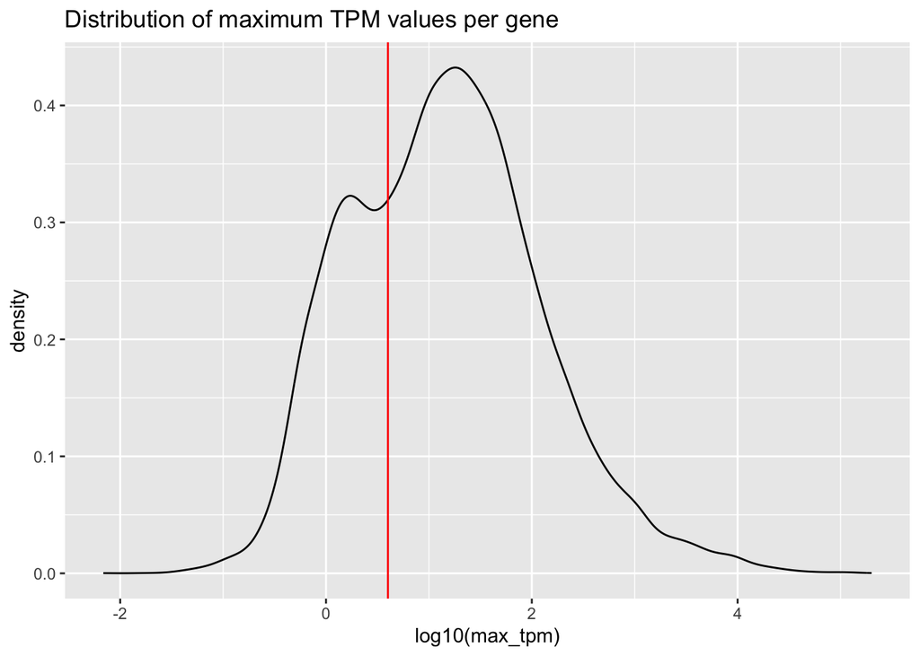

```r
bulk.data.merged.QC %>%
  pivot_longer(cols = -gene_id, names_to = "sample",values_to = "count") %>%
  group_by(sample) %>%
  dplyr::summarise(sampleReads = sum(count)) ->
  sample.count.info



bulk.data.merged.QC %>%
  pivot_longer(cols = -gene_id, names_to = "sample",values_to = "count") %>%
  inner_join(geneInfo ) %>%
  mutate(normLengthCount = count/ tx_len)->
  bulk.data.merged.QC.tpm


bulk.data.merged.QC.tpm %>%
  group_by(sample) %>%
  dplyr::summarise(sampleReads = sum(normLengthCount)) %>%
  inner_join(bulk.data.merged.QC.tpm) %>%
  mutate(tpm= (normLengthCount/sampleReads*1000000)) ->
  bulk.data.merged.QC.tpm




bulk.data.merged.QC.tpm %>% select(gene_id,sample,tx_len,count,tpm) -> bulk.data.merged.QC.tpm

write_csv(file = here("MinorGland_paper","results_allSamples_block","bulkRNA","bulk.data.merged.QC.tpm.csv.gz"),
            x = bulk.data.merged.QC.tpm)

bulk.data.merged.QC.tpm %>%
  group_by(gene_id) %>%
  summarise(max_tpm = max(tpm)) %>%
  inner_join(geneInfo) %>%
  mutate(Group = replace(silkGroup, is.na(silkGroup), "Other")) ->  bulk.data.merged.QC.tpm.summary


bulk.data.merged.QC.tpm.summary %>%ggplot(aes(log10(max_tpm ))) + geom_density() + geom_vline(xintercept = log10(4),color = "red") + labs(title = "Distribution of maximum TPM values per gene", x = "log10(max_tpm)")
```

```r
bulk.data.merged.QC.tpm.summary %>%
  select(gene_id,max_tpm) ->
  geneInfo.tpm


geneInfo.tpm %>% filter(max_tpm > 4)  ->
geneInfo.QC

geneInfo.QC = inner_join(geneInfo.QC, geneInfo)


bulk.data.merged.QC %>% filter(gene_id %in% geneInfo.QC$gene_id) %>% pivot_longer(-gene_id, values_to = "readCount", names_to = "sample") -> bulk.data.merged.QC.long
```

```r
bulk.data.merged.QC.tpm %>%
  filter(gene_id %in% geneInfo.QC$gene_id) %>%
  inner_join(sampleInfo.QC.merged) %>%
  filter(Tissue == c("Major") | MAG == c("Part")) %>%
  group_by(gene_id,Tissue, MAG) %>%
  summarise(tpm = mean(tpm)) %>%
  select(-MAG) %>%
  pivot_wider(names_from = "Tissue" , values_from = "tpm") ->
  bulk.data.merged.QC.tpm.major.wide
```

```
## `summarise()` has regrouped the output.
```

```r
MinorCounts %>%
  inner_join(geneInfo.QC) %>%
  mutate(normLengthCount = readCount/ tx_len)->
  MinorCounts.QC.tpm
MinorCounts.QC.tpm %>%
  group_by(sample) %>%
  dplyr::summarise(sampleReads = sum(normLengthCount)) %>%
  inner_join(MinorCounts.QC.tpm) %>%
  mutate(tpm= (normLengthCount/sampleReads*1000000)) ->
  MinorCounts.QC.tpm
MinorCounts.QC.tpm %>% inner_join(MinorSampleInfo) %>%
  group_by(gene_id,Tissue) %>%
  summarise(max_tpm = max(tpm)) %>%
  inner_join(geneInfo.QC) ->  MinorCounts.QC.tpm.summary
```

```
## `summarise()` has regrouped the output.
```

```r
MinorCounts.QC.tpm %>% inner_join(MinorSampleInfo)  %>%
  select(gene_id,Tissue,sample,tpm) %>%
  group_by(gene_id,Tissue) %>%
  summarise(tpm = mean(tpm)) %>%
  pivot_wider(names_from = "Tissue" , values_from = "tpm") %>%
    select(-Sac_distal_Duct)->
  MinorCounts.QC.tpm.wide
```

```
## `summarise()` has regrouped the output.
```

```r
sampleInfo.QC.merged.minor.parts = MinorSampleInfo

normExpression.minor.parts = getVSTexpression(count.df = MinorCounts,
                 md =MinorSampleInfo,
                 gi =geneInfo.QC,
                 design =  "Tissue" )
```

```
## factor levels were dropped which had no samples
```

```r
normExpression.minor.parts%>% rownames_to_column(var = "gene_id") %>%
  pivot_longer(-gene_id, values_to = "vst", names_to = "sample") %>%
  inner_join(MinorSampleInfo) %>%
  ggplot(aes(y = vst ,x = sample, fill = Tissue )) + geom_boxplot() + theme(axis.text.x = element_text(angle = 45, hjust = 1)) -> bp.before
badSamples = c("SaCe_4","SaCe_1","SaPr_5","TaPr_1","SaPr_1")


# All samples are kept here (the samples in badSamples were removed in MinorAnalysis.Rmd)
MinorSampleInfo ->
  MinorSampleInfo.QC

normExpression.minor.parts = getVSTexpression(count.df = MinorCounts,
                 md =MinorSampleInfo,
                 gi =geneInfo.QC,
                 design =  "Tissue" )
```

```
## factor levels were dropped which had no samples
```

```r
normExpression.minor.parts %>% distinct()
```

|  | TaPr_1 | SaPr_1 | SaDi_Du_1 | SaCe_1 | TaPr_2 | SaPr_2 | SaDi_Du_2 | SaCe_2 | SaDi_3 | SaDi_4 | SaDi_5 | SaPr_3 | SaPr_4 | SaPr_5 | SaCe_3 | SaCe_4 | SaCe_5 | TaPr_3 | TaPr_4 | TaPr_5 |
| --- | --- | --- | --- | --- | --- | --- | --- | --- | --- | --- | --- | --- | --- | --- | --- | --- | --- | --- | --- | --- |
| augustus_masked-000000F-processed-gene-0.7 | 6.066573 | 7.158204 | 7.657870 | 7.798643 | 3.348687 | 3.961820 | 6.244721 | 5.013814 | 6.097431 | 5.879939 | 5.590956 | 4.152867 | 5.013546 | 3.348687 | 5.592405 | 5.407225 | 4.961552 | 3.348687 | 4.054436 | 3.348687 |
| augustus_masked-000000F-processed-gene-104.5 | 6.104888 | 6.027888 | 6.122652 | 5.660140 | 5.241420 | 5.399072 | 5.770700 | 6.004384 | 5.805978 | 6.357209 | 6.478330 | 6.226032 | 6.083799 | 6.097817 | 6.258642 | 6.122043 | 5.455712 | 5.439728 | 5.898891 | 5.986238 |
| augustus_masked-000000F-processed-gene-104.6 | 3.694395 | 3.348687 | 4.564016 | 3.843307 | 3.348687 | 4.395556 | 3.944448 | 3.348687 | 4.360761 | 3.348687 | 3.777921 | 3.861206 | 3.348687 | 3.348687 | 4.452086 | 4.416046 | 3.348687 | 4.263649 | 3.348687 | 3.348687 |
| augustus_masked-000000F-processed-gene-38.1 | 3.348687 | 3.348687 | 3.348687 | 3.348687 | 3.348687 | 3.348687 | 3.348687 | 3.348687 | 3.348687 | 3.348687 | 3.348687 | 3.348687 | 3.348687 | 3.348687 | 3.348687 | 3.348687 | 3.348687 | 3.348687 | 3.348687 | 3.348687 |
| augustus_masked-000000F-processed-gene-44.17 | 5.515063 | 4.425460 | 5.198312 | 4.622013 | 5.413667 | 4.209502 | 4.444646 | 4.435369 | 5.632767 | 4.648318 | 4.086811 | 3.974774 | 4.652763 | 6.225388 | 4.211446 | 9.077051 | 4.686765 | 4.000990 | 4.054436 | 4.336140 |
| augustus_masked-000000F-processed-gene-56.1 | 6.398934 | 6.784007 | 6.987489 | 6.734198 | 5.825165 | 5.588043 | 6.846274 | 6.287508 | 6.635277 | 7.050552 | 6.234958 | 6.985760 | 6.103044 | 6.304358 | 6.932029 | 6.589764 | 5.811624 | 6.167693 | 6.152580 | 5.326066 |
| augustus_masked-000000F-processed-gene-57.4 | 4.419760 | 4.556280 | 5.698183 | 3.635186 | 4.800749 | 4.209502 | 5.090320 | 3.901574 | 3.768902 | 4.230893 | 3.953518 | 3.712040 | 4.589769 | 4.447756 | 3.348687 | 4.247598 | 4.035462 | 4.000990 | 4.870964 | 4.336140 |
| augustus_masked-000000F-processed-gene-60.2 | 9.562462 | 9.428585 | 8.832032 | 8.983761 | 6.829328 | 7.140053 | 6.862877 | 7.687639 | 7.717667 | 7.499130 | 7.797597 | 7.154046 | 7.541950 | 6.866392 | 7.354107 | 7.710939 | 7.877638 | 7.278712 | 7.038849 | 6.797433 |
| augustus_masked-000000F-processed-gene-60.3 | 3.836436 | 4.272558 | 4.165576 | 4.241833 | 3.348687 | 4.906351 | 4.583452 | 4.665132 | 4.360761 | 4.331356 | 4.781476 | 4.472148 | 4.079681 | 4.746786 | 4.642505 | 4.600922 | 4.185976 | 4.762482 | 4.548434 | 3.348687 |
| augustus_masked-000000F-processed-gene-64.7 | 3.348687 | 4.152102 | 3.789472 | 3.348687 | 3.348687 | 3.348687 | 4.185441 | 3.348687 | 3.348687 | 3.348687 | 3.348687 | 3.348687 | 3.348687 | 3.348687 | 3.348687 | 3.348687 | 3.348687 | 3.348687 | 3.348687 | 3.348687 |

[output cut: 9990 more lines]

```r
MinorCounts.QC.tpm %>%
  inner_join(MinorSampleInfo) %>%
  mutate(sample = factor(sample, levels = sampleOrder)) %>%
  ggplot(aes(y = log10(tpm) ,x = sample, fill = Tissue )) +
  geom_boxplot()+
  theme_light()+ theme(axis.text.x = element_text(angle = 45, hjust = 1)) +
  scale_fill_manual(values = BulkPartMinor) -> tpm.before
normExpression.minor.parts%>% rownames_to_column(var = "gene_id") %>%
  pivot_longer(-gene_id, values_to = "vst", names_to = "sample") %>%
  inner_join(MinorSampleInfo.QC) %>%
  mutate(sample = factor(sample, levels = sampleOrder)) %>%
  ggplot(aes(y = vst ,x = sample, fill = Tissue )) + geom_boxplot() +
  theme_light()+ theme(axis.text.x = element_text(angle = 45, hjust = 1)) +
  scale_fill_manual(values = BulkPartMinor)-> bp.after
tpm.before/bp.after+ plot_layout(guides = "collect") -> RNA1.supp.plot
#RNA1.supp.plot
#ggsave("figures/supplementaryFigures/supplementaryFigureRNA1.pdf",width = 160,height = 160,units = "mm",plot = suppFigProt3)
```

## Expression of silkProteins

```r
MinorCounts.QC.tpm  %>%
  inner_join(sampleInfo.QC.merged.minor.parts) %>%
  inner_join(geneInfo.QC) %>%
  filter(grepl("MiSp",geneName))  %>%
  select(geneNameProtein,Tissue,sample,tpm) ->
  MiSpExpression
```

[output not shown]

```r
MinorCounts.QC.tpm  %>%
  inner_join(sampleInfo.QC.merged.minor.parts) %>%
  inner_join(geneInfo.QC) %>%
  filter(!is.na(silkGroup)) %>%
  select(geneNameProtein,Tissue,sample,tpm)->
  silkProteins.expression
```

[output not shown]

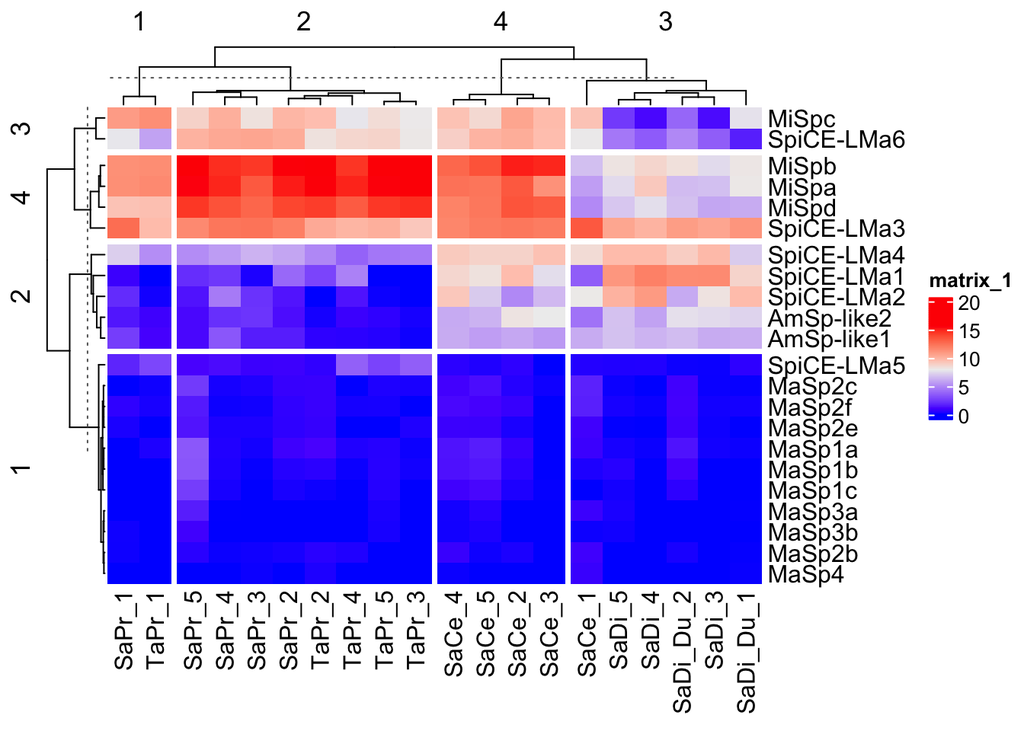

```r
bind_rows(MiSpExpression,silkProteins.expression) %>%
  mutate(log2TPM = log2(tpm+1))->
  silkProteins.expression

silkProteins.expression %>%
  select(geneNameProtein,sample,log2TPM) %>%
  pivot_wider(names_from = "sample", values_from ="log2TPM") %>%
  column_to_rownames("geneNameProtein")->silkProteins.expression.wide



ComplexHeatmap::Heatmap(silkProteins.expression.wide, column_km = 4, row_km = 4)
```

```r
pdf(here("MinorGland_paper","figures_allSamples_block","supplementaryFigures","bulkRNA","silkProteins.heatMap.pdf"), width = 6, height = 4)
ComplexHeatmap::Heatmap(silkProteins.expression.wide, column_split =  4, row_split = 4)
dev.off()
```

## PCA

```r
normExpression.minor.parts[,as.character(MinorSampleInfo.QC$sample)] ->normExpression.minor.parts


row_vars <- apply(normExpression.minor.parts, 1, var)

top_n <- 1000
top_var_rows <- normExpression.minor.parts[order(row_vars, decreasing = TRUE)[1:top_n], ]

mir.pca <- prcomp(t(top_var_rows), center = TRUE, scale = TRUE)
e.var = (mir.pca[['sdev']]^2 / sum(mir.pca[['sdev']]^2))
e.var = as.data.frame( e.var )
e.var$PC = as.factor(1:nrow(e.var))
e.var$Variance = e.var$e.var*100
e.var$CumulativeVariance = cumsum(e.var$Variance)
qplot(PC, Variance, data=e.var, geom = c("point")
      , ylim = c(0,max(e.var$Variance)+5)
      ,ylab = "Variance (%)")+ theme_light() -> PCAvariance

ggsave(here("MinorGland_paper","figures_allSamples_block","supplementaryFigures","bulkRNA","bulkRNA.PCA.variance.pdf"),plot = PCAvariance,
       width = 2000,height = 500,units = "px")



mir.pca$x %>% as.data.frame()%>%
  rownames_to_column(var = "sample") %>%
  select(sample,PC1,PC2,PC3,PC4,PC5,PC6,PC7) ->
  sampleInfo.minor.parts.PCA

sampleInfo.minor.parts.PCA %>% inner_join(sampleInfo.QC.merged.minor.parts) %>%
  select(PC1,PC2,,PC3,PC4,PC5,Tissue) %>%
  ggpairs(aes(color = Tissue, alpha = 0.8) ,
          upper = "blank",
          , lower = list(continuous = "points", combo = "box_no_facet"))+
  scale_color_manual(values = BulkPartMinor) +
  scale_fill_manual(values = BulkPartMinor) + theme_light()   ->
  RNAqual2.check


ggsave(here("MinorGland_paper","figures_allSamples_block","supplementaryFigures","bulkRNA","bulkRNA.PCA.plot.pdf")
       ,plot = RNAqual2.check,
       width = 2000,height = 2000,units = "px")



sampleInfo.minor.parts.PCA %>% inner_join(sampleInfo.QC.merged.minor.parts) %>%
  select(PC1,PC2,Tissue) %>%
  ggpairs(aes(color = Tissue, alpha = 0.8) ,
          upper = "blank",
          , lower = list(continuous = "points", combo = "box_no_facet"))+
  scale_color_manual(values = BulkPartMinor) +
  scale_fill_manual(values = BulkPartMinor) + theme_light()   ->
  RNAqual3.check



mir.pca$rotation %>%
  as.data.frame() %>%
  rownames_to_column(var = "gene_id") %>%
  select(gene_id,PC1,PC2) %>%
  inner_join(geneInfo.QC) %>%
  select(geneNameProtein,PC1,PC2)->
  minor.parts.PCA.loading


mir.pca$x %>%
  as.data.frame() %>%
  rownames_to_column(var = "sample") %>%
  select(sample,PC1,PC2) %>%
  inner_join(sampleInfo.QC.merged.minor.parts) ->
  minor.parts.PCA


write_csv(file = here("MinorGland_paper","results_allSamples_block","bulkRNA","minor.parts.PCA.loading.csv.gz"),
            x = minor.parts.PCA.loading)

write_csv(file = here("MinorGland_paper","results_allSamples_block","bulkRNA","minor.parts.PCA.csv.gz"),
            x = minor.parts.PCA)
```

```r
normExpression.minor.parts[,as.character(MinorSampleInfo.QC$sample)] ->normExpression.minor.parts
# Non-duct samples (the original used the first 13 columns, which were the non-duct samples after QC)
normExpression.minor.parts[, MinorSampleInfo.QC %>%
                             filter(Tissue != "Sac_distal_Duct") %>%
                             pull(sample) %>% as.character()] -> n2

row_vars <- apply(n2, 1, var)

top_n <- 2000
top_var_rows <- n2[order(row_vars, decreasing = TRUE)[1:top_n], ]


mir.pca <- prcomp(t(top_var_rows), center = TRUE, scale = TRUE)
e.var = (mir.pca[['sdev']]^2 / sum(mir.pca[['sdev']]^2))
e.var = as.data.frame( e.var )
e.var$PC = as.factor(1:nrow(e.var))
e.var$Variance = e.var$e.var*100
e.var$CumulativeVariance = cumsum(e.var$Variance)
qplot(PC, Variance, data=e.var, geom = c("point")
      , ylim = c(0,max(e.var$Variance)+5)
      ,ylab = "Variance (%)")+ theme_light() -> variance

#PCAvariance[["minor.part"]] = e.var


mir.pca$x %>% as.data.frame()%>%
  rownames_to_column(var = "sample") %>%
  select(sample,PC1,PC2,PC3,PC4,PC5,PC6,PC7) ->
  sampleInfo.minor.parts.PCA

sampleInfo.minor.parts.PCA %>% inner_join(sampleInfo.QC.merged.minor.parts) %>%
  select(PC1,PC2,Tissue) %>%
  ggpairs(aes(color = Tissue, alpha = 0.8) ,
          upper = "blank",
          , lower = list(continuous = "points", combo = "box_no_facet"))+
  scale_color_manual(values = BulkPartMinor) +
  scale_fill_manual(values = BulkPartMinor) + theme_light()   ->
  RNAqual2.check


sampleInfo.minor.parts.PCA %>% inner_join(sampleInfo.QC.merged.minor.parts) %>%
  select(PC1,PC2,Tissue) %>%
  ggplot(aes(x =Tissue ,y = PC1,  fill = Tissue))+
  geom_boxplot(alpha =0.8) +
  scale_color_manual(values = BulkPartMinor) +
  scale_fill_manual(values = BulkPartMinor)  + theme_light()  + theme(legend.position = "none")+ theme(axis.text.x = element_text(angle = 45, hjust = 1))  ->
  FigurePCA.minor.parts



variance+FigurePCA.minor.parts ->Figure2.E.PCA.minor.parts

ggsave(here("MinorGland_paper","figures_allSamples_block","figure2","Figure2.E.PCA.minor.parts.pdf")
       ,plot = Figure2.E.PCA.minor.parts,
       width = 160,height = 80,units = "mm")
```

## DEseq2

### Compare Minor parts

#### Including duct samples

Not blocked: duct and Sac_distal come from different individuals. Gene universe as in the original (proteomics-expressed QC genes).

```r
MinorSampleInfo.QC  ->
  MinorSampleInfo.QC.MiAG

geneInfo.QC %>% inner_join(minorProteomics.expressed)-> geneInfo.QC.minor.prot



MinorSampleInfo.QC.MiAG %>%
  mutate(Tissue = as.character(Tissue)) %>%
  mutate(sample = as.character(sample)) ->
  MinorSampleInfo.QC.MiAG


dds.MiAG = getDEseq2Object(count.df = MinorCounts,
                 md =MinorSampleInfo.QC.MiAG,
                 gi =geneInfo.QC.minor.prot,
                 design =  "Tissue" )
dds.MiAG = DESeq(dds.MiAG)


resDAp <-results(dds.MiAG,
               contrast =
                 list(c("designSac_distal_Duct"),c("designSac_distal")),
               listValues = c(1,-1))
as.data.frame(resDAp) %>%
  rownames_to_column(var = "gene_id") %>%
  mutate(Tissue = "Duct") %>%
  select(gene_id,Tissue,baseMean,log2FoldChange,padj) %>%
  arrange(padj) %>% inner_join(geneInfo) %>%
  filter(!is.na(padj))->
  geneInfo.Dap.DEseq2



geneInfo.Dap.DEseq2 %>%
  filter(padj < 0.05 &log2FoldChange >log2(5) ) ->
  DEseq.minor.parts.duct.results
```

#### Exluding the duct samples

Gene filter: the weakest non-duct sample in at least one part must exceed 0.1 TPM.

```r
MinorCounts %>%
  inner_join(geneInfo %>% select(gene_id, tx_len), by = "gene_id") %>%
  mutate(rpk = readCount / tx_len) %>%
  group_by(sample) %>%
  mutate(tpm = rpk / sum(rpk) * 1e6) %>%
  ungroup() %>%
  inner_join(MinorSampleInfo %>%
               mutate(sample = as.character(sample), Tissue = as.character(Tissue)) %>%
               select(sample, Tissue), by = "sample") %>%
  filter(Tissue != "Sac_distal_Duct") %>%
  group_by(gene_id, Tissue) %>%
  summarise(minTPM = min(tpm), .groups = "drop") %>%
  group_by(gene_id) %>%
  summarise(bestMinTPM = max(minTPM)) %>%
  filter(bestMinTPM > 0.1) ->
  minorParts.expressed.weakest

geneInfo.QC %>%
  filter(gene_id %in% minorParts.expressed.weakest$gene_id) ->
  geneInfo.QC.parts.tested

geneInfo %>%
  filter(geneName %in% minorProteomics.expressed$geneName) %>%
  pull(gene_id) ->
  protGenes
```

```r
MinorSampleInfo.QC %>%
  filter(Tissue != "Sac_distal_Duct")   ->
  MinorSampleInfo.QC.MiAG

geneInfo.QC %>% inner_join(minorProteomics.expressed)-> geneInfo.QC.minor.prot



MinorSampleInfo.QC.MiAG %>%
  mutate(Tissue = as.character(Tissue)) %>%
  mutate(sample = as.character(sample)) ->
  MinorSampleInfo.QC.MiAG


dds.MiAG = getDEseq2Object(count.df = MinorCounts,
                 md =MinorSampleInfo.QC.MiAG,
                 gi =geneInfo.QC.parts.tested,
                 design =  "Tissue" )

# Block on individual; Tail_proximal is the reference level
dds.MiAG$design <- relevel(dds.MiAG$design, ref = "Tail_proximal")
dds.MiAG$individual <- factor(dds.MiAG$individual)
design(dds.MiAG) <- ~ individual + design
dds.MiAG = DESeq(dds.MiAG)
resultsNames(dds.MiAG)
```

```
## [1] "Intercept"
## [2] "individual_ind2_vs_ind1"
## [3] "individual_ind3_vs_ind1"
## [4] "individual_ind4_vs_ind1"
## [5] "individual_ind5_vs_ind1"
## [6] "design_Sac_center_vs_Tail_proximal"
## [7] "design_Sac_distal_vs_Tail_proximal"
## [8] "design_Sac_proximal_vs_Tail_proximal"
```

```r
#Sac_center_vs_Tail_proximal
resScTp <-results(dds.MiAG, name = "design_Sac_center_vs_Tail_proximal")

as.data.frame(resScTp) %>%
  rownames_to_column(var = "gene_id") %>%
  mutate(Tissue = "Sac_center") %>%
  select(gene_id,Tissue,baseMean,log2FoldChange,padj) %>%
  arrange(padj) %>% inner_join(geneInfo) %>%
  filter(!is.na(padj))->
  geneInfo.ScTp.DEseq2


#ZoneC
resSdTp <-results(dds.MiAG, name = "design_Sac_distal_vs_Tail_proximal")
as.data.frame(resSdTp) %>%
  rownames_to_column(var = "gene_id") %>%
  mutate(Tissue = "Sac_distal") %>%
  select(gene_id,Tissue,baseMean,log2FoldChange,padj) %>%
  arrange(padj) %>% inner_join(geneInfo) %>%
  filter(!is.na(padj))->
  geneInfo.SdTp.DEseq2



resSpAp <-results(dds.MiAG, name = "design_Sac_proximal_vs_Tail_proximal")
as.data.frame(resSpAp) %>%
  rownames_to_column(var = "gene_id") %>%
  mutate(Tissue = "Sac_proximal") %>%
  select(gene_id,Tissue,baseMean,log2FoldChange,padj) %>%
  arrange(padj) %>% inner_join(geneInfo) %>%
  filter(!is.na(padj))->
  geneInfo.SpAp.DEseq2

bind_rows(geneInfo.SpAp.DEseq2,geneInfo.ScTp.DEseq2,geneInfo.SdTp.DEseq2)->
  DEseq.minor.parts.results



DEseq.minor.parts.results %>% select(gene_id,Tissue,baseMean,log2FoldChange,padj) %>%
  pivot_wider(names_from = "Tissue", values_from = c("baseMean","log2FoldChange","padj")) ->
  DEseq.minor.parts.results.wide
```

```r
DEseq.minor.parts.results %>%
  group_by(gene_id) %>%
  summarise(minPadj = min(padj), maxFoldChange = max(abs(log2FoldChange))) %>%
  arrange(minPadj) %>%
  inner_join(DEseq.minor.parts.results) %>%
  filter(minPadj < 0.05 &maxFoldChange >log2(5) ) %>%
  filter(gene_id %in% protGenes) ->
  DEseq.minor.parts.A.results.pruned

DEseq.minor.parts.A.results.pruned %>%
  select(geneName,signalP,log2FoldChange,baseMean,Tissue) %>%
  pivot_wider(values_from = "log2FoldChange", names_from = "Tissue") ->
  DEseq.parts.A.results.pruned.wide


DEseq.parts.A.results.pruned.wide%>% filter(signalP == "Yes") %>%
  inner_join(geneInfo)  %>%
  select(geneNameProtein,Sac_proximal,Sac_center,Sac_distal) %>%
  column_to_rownames("geneNameProtein") ->
  DEseq.parts.A.results.pruned.signalP.wide


DEseq.minor.parts.A.results.pruned %>% inner_join(geneInfo) %>%
  distinct(geneNameProtein, Term) %>%
  group_by(Term) %>% summarise(n = n())
```

| Term | n |
| --- | --- |
| MiSp | 4 |
| AmSp-like | 2 |
| SpiCE | 6 |
| SignalPeptide | 27 |
| RibosomalProteins | 5 |
| NoSignalPeptide | 51 |

```r
DEseq.minor.parts.A.results.pruned %>%
  filter(log2FoldChange > 0) %>%
  group_by (geneName) %>%
  arrange(-log2FoldChange) %>%
  slice_head(n = 1)  ->
  geneLocations

DEseq.minor.parts.A.results.pruned %>%
  filter(abs(log2FoldChange) == maxFoldChange) %>%
  mutate(Tissue = replace(Tissue, log2FoldChange < 0,"Tail_proximal"))  %>%
  arrange(Tissue,log2FoldChange)-> DEseq.minor.parts.A.results.pruned.location


DEseq.minor.parts.A.results.pruned.location %>%
  filter(Tissue == "Tail_proximal") %>%
  select(geneNameProtein) %>%
  inner_join(geneLocations) %>%
  select(geneNameProtein,Tissue)-> DEseq.minor.parts.A.results.pruned.location.changed

DEseq.minor.parts.A.results.pruned.location  %>%
  select(geneNameProtein,Tissue) %>%
  filter(!geneNameProtein %in% DEseq.minor.parts.A.results.pruned.location.changed$geneNameProtein) %>%
  bind_rows(DEseq.minor.parts.A.results.pruned.location.changed) %>%
  arrange(Tissue) %>%
  ungroup() ->
  DEseq.minor.parts.A.results.pruned.location



DEseq.minor.parts.duct.results %>%
  select(geneNameProtein,Tissue) %>%
  bind_rows(DEseq.minor.parts.A.results.pruned.location) ->
  DEseq.minor.parts.location


data.frame(mir.pca$rotation) %>%
  rownames_to_column(var = "gene_id") %>%
  inner_join(geneInfo) %>%
  inner_join(DEseq.minor.parts.A.results.pruned.location) %>%
  ggplot(aes(x = PC1, y = PC2, color = Tissue, label = geneNameProtein)) +
  geom_point() +
  theme_light() +
  theme(legend.position = "bottom") -> DE.distribution


data.frame(mir.pca$rotation) %>%
  rownames_to_column(var = "gene_id") %>%
  inner_join(geneInfo) %>%
  select(geneNameProtein, PC1,PC2) ->
  PCA.rotation.data






write_csv(file = here("MinorGland_paper","results_allSamples_block","bulkRNA","DEseq.minor.parts.location.csv.gz"),
            x = DEseq.minor.parts.location)


11
```

```
## [1] 11
```

### Compare glands

```r
geneInfo.QC %>% inner_join(minorProteomics.expressed)-> geneInfo.QC.minor.prot


sampleInfo.QC.merged %>%
  mutate(Tissue = as.character(Tissue)) %>%
  mutate(sample = as.character(sample)) %>%
  filter(Tissue %in% c("Head","Major","Minor"))->
  sampleInfo.QC.merged.DE



dds.Gland = getDEseq2Object(count.df = bulk.data.merged.QC.long,
                 md =sampleInfo.QC.merged.DE,
                 gi =geneInfo.QC.minor.prot,
                 design =  "Tissue" )
dds.Gland = DESeq(dds.Gland)


resultsNames(dds.Gland)
```

```
## [1] "designHead"  "designMajor" "designMinor"
```

```r
#Sac_center_vs_Tail_proximal

resMiHe <-results(dds.Gland,
               contrast =
                 list(c("designMinor"),c("designHead")),
               listValues = c(1,-1))

as.data.frame(resMiHe) %>%
  rownames_to_column(var = "gene_id") %>%
  mutate(Tissue = "Head") %>%
  select(gene_id,Tissue,baseMean,log2FoldChange,padj) %>%
  arrange(padj) %>% inner_join(geneInfo) %>%
  filter(!is.na(padj))->
  geneInfo.MiHe.DEseq2


resMiMa <-results(dds.Gland,
               contrast =
                 list(c("designMinor"),c("designMajor")),
               listValues = c(1,-1))

as.data.frame(resMiMa) %>%
  rownames_to_column(var = "gene_id") %>%
  mutate(Tissue = "Major") %>%
  select(gene_id,Tissue,baseMean,log2FoldChange,padj) %>%
  arrange(padj) %>% inner_join(geneInfo) %>%
  filter(!is.na(padj))->
  geneInfo.MiMa.DEseq2



resMaHe <-results(dds.Gland,
               contrast =
                 list(c("designMajor"),c("designHead")),
               listValues = c(1,-1))

as.data.frame(resMaHe) %>%
  rownames_to_column(var = "gene_id") %>%
  mutate(Tissue = "Major_Head") %>%
  select(gene_id,Tissue,baseMean,log2FoldChange,padj) %>%
  arrange(padj) %>% inner_join(geneInfo) %>%
  filter(!is.na(padj))->
  geneInfo.MaHe.DEseq2


bind_rows(geneInfo.MiMa.DEseq2,geneInfo.MiHe.DEseq2,geneInfo.MaHe.DEseq2)->
  DEseq.minor.gland.results

write_csv(DEseq.minor.gland.results,here("MinorGland_paper","results_allSamples_block","bulkRNA",
                      "DEseq2_tissue.csv.gz"))

DEseq.minor.gland.results %>%
  group_by(gene_id) %>%
  summarise(minPadj = min(padj), maxFoldChange = max(log2FoldChange)) %>%
  arrange(minPadj) %>%
  inner_join(DEseq.minor.gland.results) %>%
  filter(minPadj < 0.05,maxFoldChange >log2(5) ) %>%
  filter(signalP == "Yes")->
  DEseq.minor.gland.pruned.results


DEseq.minor.gland.results %>%
  filter(geneNameProtein %in%  rownames(DEseq.parts.A.results.pruned.signalP.wide)) %>%
  mutate(sigLevel = "None") %>%
  mutate(sigLevel = replace(sigLevel, padj < 0.1, "**")) %>%
  mutate(sigLevel = replace(sigLevel, padj < 0.05, "***")) %>%
  mutate(sigLevel = replace(sigLevel, padj < 0.0001, "****")) %>%
  mutate(dir = "Up") %>%
  mutate(dir = replace(dir, log2FoldChange < 0, "Down")) %>%
  select(geneNameProtein,Tissue,log2FoldChange,sigLevel,dir)->
  DEseq.minor.gland.HM.results



#DEseq.parts.A.results.pruned.signalP.wide = DEseq.parts.A.results.pruned.signalP.wide[DEseq.minor.gland.results.2$geneNameProtein,]

#DEseq.parts.A.results.pruned.signalP.wide


geneInfo.MiHe.DEseq2%>%
  filter(padj < 0.05,log2FoldChange >log2(5) ) %>%
  inner_join(geneInfo) %>%
  select(geneNameProtein,Term) -> miHe.final


DEseq.minor.parts.A.results.pruned %>% inner_join(geneInfo) %>%
  distinct(geneNameProtein, Term) %>% inner_join(miHe.final) %>%
  group_by(Term) %>% summarise(n = n())
```

| Term | n |
| --- | --- |
| MiSp | 4 |
| AmSp-like | 2 |
| SpiCE | 6 |
| SignalPeptide | 17 |
| RibosomalProteins | 1 |
| NoSignalPeptide | 20 |

```r
DEseq.minor.gland.results %>%
  filter(Tissue == "Head")  %>%
  filter(padj < 0.05) %>%
  filter(log2FoldChange >  log2(5)) ->
  DEseq.minor.head.results



DEseq.minor.head.results %>% inner_join(interpro5) %>%
  group_by(interpro_accession,interpro_description) %>%
  summarise(n = n()) %>%
  arrange(-n)
```

| interpro_accession | interpro_description | n |
| --- | --- | --- |
| NA | NA | 1056 |
| IPR002172 | Low-density lipoprotein (LDL) receptor class A repeat | 165 |
| IPR036055 | LDL receptor-like superfamily | 80 |
| IPR000033 | LDLR class B repeat | 66 |
| IPR000742 | EGF-like domain | 33 |
| IPR036612 | K Homology domain, type 1 superfamily | 30 |
| IPR002347 | Short-chain dehydrogenase/reductase SDR | 28 |
| IPR023415 | Low-density lipoprotein (LDL) receptor class A, conserved site | 20 |
| IPR004087 | K Homology domain | 15 |
| IPR001680 | WD40 repeat | 14 |

[output cut: 194 more lines]

```r
GOI_common = c("LASC007034","LASC0011995","lman2l",
        "x975_2","SpiCE-LMa5","AmSp-like1","AmSp-like2",
        "SpiCE-LMa3","SpiCE-LMa1",
        "SpiCE-LMa2","SpiCE-LMa4",
        "LASC009784","spa",
        "LASC007099","LASC017532")
geneInfo %>%
  left_join(interpro5) %>%
  filter(geneNameProtein %in%  GOI_common)
```

[output not shown]

[output cut: 183 more lines]

```r
geneInfo %>% filter(grepl("SpiCE",geneNameProtein2 )) %>% select(geneNameProtein, geneNameProtein2) %>%
  arrange(geneNameProtein2)
```

| geneNameProtein | geneNameProtein2 |
| --- | --- |
| SpiCE-LMa1 | SpiCE-LMa1 |
| LASC004595 | SpiCE-LMa10 |
| LASC009784 | SpiCE-LMa11 |
| cht10_chi3l2 | SpiCE-LMa12 |
| x975_2 | SpiCE-LMa13 |
| LASC005034 | SpiCE-LMa14 |
| pebp1_2 | SpiCE-LMa15 |
| sod1_sod-1 | SpiCE-LMa16 |
| LASC010830 | SpiCE-LMa17 |
| SpiCE-LMa2 | SpiCE-LMa2 |

[output cut: 7 more lines]

```r
interpro5  %>%
   filter(interpro_accession == "IPR043070") %>%
   group_by(geneName ) %>%
   summarise(n = n())  %>%
  arrange(-n)  -> IPR043070


DEseq.minor.gland.results%>%
  select(gene_id,Tissue,log2FoldChange,padj) %>%

  pivot_wider(names_from = "Tissue", values_from = c("log2FoldChange","padj")) ->
  DEseq.minor.glands.results.wide


DEseq.minor.glands.results.wide %>%
  rename(log2FoldChange_Major_vs_Head = "log2FoldChange_Major_Head") %>%
  rename(padj_Major_vs_Head = "padj_Major_Head") %>%
  rename(log2FoldChange_Minor_vs_Head = "log2FoldChange_Head") %>%
  rename(padj_Minor_vs_Head = "padj_Head") %>%
  rename(log2FoldChange_Minor_vs_Major = "log2FoldChange_Major") %>%
  rename(padj_Minor_vs_Major = "padj_Major") ->
  DEseq.minor.glands.results.wide
```

```r
geneInfo.QC %>% inner_join(minorProteomics.expressed)-> geneInfo.QC.minor.prot


sampleInfo.QC.merged %>%
  mutate(Tissue = as.character(Tissue)) %>%
  mutate(sample = as.character(sample)) %>%
  filter(Tissue %in% c("Head","Major","Minor"))->
  sampleInfo.QC.merged.DE



dds.Gland = getDEseq2Object(count.df = bulk.data.merged.QC.long,
                 md =sampleInfo.QC.merged.DE,
                 gi =geneInfo.QC,
                 design =  "Tissue" )
dds.Gland = DESeq(dds.Gland)

resMiHe <-results(dds.Gland,
               contrast =
                 list(c("designMinor"),c("designHead")),
               listValues = c(1,-1))

as.data.frame(resMiHe) %>%
  rownames_to_column(var = "gene_id") %>%
  mutate(Tissue = "Head") %>%
  select(gene_id,Tissue,baseMean,log2FoldChange,padj) %>%
  arrange(padj) %>% inner_join(geneInfo) %>%
  filter(!is.na(padj))->
  geneInfo.MiHe.DEseq2


resMiMa <-results(dds.Gland,
               contrast =
                 list(c("designMinor"),c("designMajor")),
               listValues = c(1,-1))

as.data.frame(resMiMa) %>%
  rownames_to_column(var = "gene_id") %>%
  mutate(Tissue = "Major") %>%
  select(gene_id,Tissue,baseMean,log2FoldChange,padj) %>%
  arrange(padj) %>% inner_join(geneInfo) %>%
  filter(!is.na(padj))->
  geneInfo.MiMa.DEseq2



resMaHe <-results(dds.Gland,
               contrast =
                 list(c("designMajor"),c("designHead")),
               listValues = c(1,-1))

as.data.frame(resMaHe) %>%
  rownames_to_column(var = "gene_id") %>%
  mutate(Tissue = "Major_Head") %>%
  select(gene_id,Tissue,baseMean,log2FoldChange,padj) %>%
  arrange(padj) %>% inner_join(geneInfo) %>%
  filter(!is.na(padj))->
  geneInfo.MaHe.DEseq2


bind_rows(geneInfo.MiMa.DEseq2,geneInfo.MiHe.DEseq2,geneInfo.MaHe.DEseq2)->
  DEseq.minor.gland.results

write_csv(DEseq.minor.gland.results,here("MinorGland_paper","results_allSamples_block","bulkRNA",
                      "DEseq2_tissue.csv.gz"))
```

### Common genes

```r
geneInfo %>%
  filter(signalP == "Yes") ->
  signalP

DEseq.minor.gland.results %>%
  filter(Tissue == "Head")  %>%
  filter(padj < 0.05) %>%
  filter(log2FoldChange >  log2(5)) %>%
  select(geneNameProtein,signalP,Term)->
  DEseq.gland.sig


DEseq.minor.parts.results %>%
  select(-Tissue) %>%
  right_join(DEseq.minor.parts.A.results.pruned.location)%>%
  select(geneNameProtein,signalP,Term,Tissue) %>%
  distinct()->
  DEseq.part.sig
DEseq.part.sig %>%
  arrange(Tissue)
```

| geneNameProtein | signalP | Term | Tissue |
| --- | --- | --- | --- |
| LASC005273 | No | NoSignalPeptide | Sac_center |
| SpiCE-LMa3 | Yes | SpiCE | Sac_center |
| mvp | No | NoSignalPeptide | Sac_center |
| LASC011699 | No | NoSignalPeptide | Sac_center |
| LASC016310 | No | NoSignalPeptide | Sac_center |
| LASC013620 | Yes | SignalPeptide | Sac_center |
| grn_6 | Yes | SignalPeptide | Sac_center |
| grhpr_7 | No | NoSignalPeptide | Sac_center |
| cg3556_2 | Yes | SignalPeptide | Sac_center |
| MiSpc | Yes | MiSp | Sac_center |

[output cut: 85 more lines]

```r
DEseq.part.sig %>%
  filter(geneNameProtein %in% DEseq.gland.sig$geneNameProtein) %>%
  select(geneNameProtein,Tissue,Term)->
  DEseq.common

genesOfInterest = list(signalP$geneNameProtein, DEseq.part.sig$geneNameProtein, DEseq.gland.sig$geneNameProtein)


DEseq.common %>%
  filter(Term != "RibosomalProteins") %>%
  filter(Term != "NoSignalPeptide") ->
DEseq.common.27

DEseq.common.27 %>%
  arrange(Term,Tissue)
```

| geneNameProtein | Tissue | Term |
| --- | --- | --- |
| MiSpc | Sac_center | MiSp |
| MiSpa | Tail_proximal | MiSp |
| MiSpd | Tail_proximal | MiSp |
| MiSpb | Tail_proximal | MiSp |
| AmSp-like1 | Sac_distal | AmSp-like |
| AmSp-like2 | Sac_distal | AmSp-like |
| SpiCE-LMa3 | Sac_center | SpiCE |
| SpiCE-LMa2 | Sac_distal | SpiCE |
| SpiCE-LMa4 | Sac_distal | SpiCE |
| SpiCE-LMa1 | Sac_distal | SpiCE |

[output cut: 20 more lines]

```r
DEseq.minor.gland.results %>%
  filter(Tissue == "Head")  %>%
  arrange(Term,geneNameProtein)
```

| gene_id | Tissue | baseMean | log2FoldChange | padj | geneName | geneNameProtein | silkGroup | signalP | scGeneName | lascID | product | tx_name | tx_len | Protein.ID | Sequence | Length | Molecular.Weight..MW. | Isoelectric.Point..pI. | Amino.Acid.Counts | Amino.Acid.Percentages | Extinction.coeff..M.1.cm.1..with.reduced.cysteines..with.disulfide.bridges. | aromaticity | charge.at.pH5.7 | charge.at.pH6.5 | charge.at.pH7 | charge.at.pH7.6 | gravy..Grand.Average.of.Hydropathy. | sec.structure.fraction..Helix..Turn..Sheet. | Term | … |
| --- | --- | --- | --- | --- | --- | --- | --- | --- | --- | --- | --- | --- | --- | --- | --- | --- | --- | --- | --- | --- | --- | --- | --- | --- | --- | --- | --- | --- | --- | --- |
| evm-000071F-processed-gene-30.32-GeneA | Head | 6.637110e+04 | 1.211711e+01 | 1.026882e-18 | MiSpa | MiSpa | NA | Yes | MiSpa | LASC007254 | hypothetical, protein | evm-000071F-processed-gene-30.32-GeneA-mRNA-1 | 8455 | evm-000071F-processed-gene-30.32-GeneA-mRNA-1 | MQWTTRFSLFFLILFIQGFLAHGQQIWTNPDAAMSMTNNLVQCAGRSGVLTADQMDDMGM…… | 2812 | 219069.0929 | 8.709373 | {'A': 919, 'C': 2, 'D': 16, 'E': 14, 'F': 15, 'G': 1177, 'H': 3, 'I': 19, 'K': 6, 'L': 25, 'M': 19, 'N': 29, 'P': 6, 'Q': 66, 'R': 34, 'S': 201, 'T': 46, 'V': 48, 'W': 2, 'Y': 165} | {'A': 0.32681365576102417, 'C': 0.0007112375533428165, 'D': 0.005689900426742532, 'E': 0.004978662873399715, 'F': 0.005334281650071123, 'G': 0.4185633001422475, 'H': 0.0010668563300142249, 'I': 0.0067… | (256850, 256975) | 0.064722617 | 1.301289e+01 | 1.057648e+01 | 9.628185e+00 | 8.529550e+00 | 2.155761e-01 | (0.09743954480796586, 0.5024893314366998, 0.34743954480796585) | MiSp | … |
| evm-000071F-processed-gene-30.32-GeneB | Head | 1.091705e+05 | 1.250800e+01 | 1.229013e-20 | MiSpb | MiSpb | NA | Yes | MiSpb | LASC007257 | hypothetical, protein | evm-000071F-processed-gene-30.32-GeneB-mRNA-1 | 7878 | evm-000071F-processed-gene-30.32-GeneB-mRNA-1 | MQWTTRFSLFFLILFIQGFLAHGQQIWTNPDAAMSMTNNLVQCAGRSGVLTADQMDDMGM…… | 2626 | 205232.7721 | 8.990455 | {'A': 871, 'C': 2, 'D': 16, 'E': 9, 'F': 16, 'G': 1080, 'H': 3, 'I': 23, 'K': 6, 'L': 28, 'M': 19, 'N': 31, 'P': 7, 'Q': 60, 'R': 35, 'S': 186, 'T': 37, 'V': 44, 'W': 2, 'Y': 151} | {'A': 0.3316831683168317, 'C': 0.0007616146230007616, 'D': 0.006092916984006093, 'E': 0.003427265803503427, 'F': 0.006092916984006093, 'G': 0.4112718964204113, 'H': 0.0011424219345011425, 'I': 0.00875… | (235990, 236115) | 0.064356436 | 1.874739e+01 | 1.653674e+01 | 1.562811e+01 | 1.458149e+01 | 2.421554e-01 | (0.10053313023610053, 0.49657273419649656, 0.353008377760853) | MiSp | … |
| maker-000071F-augustus-gene-30.4 | Head | 1.868818e+03 | 1.365098e+01 | 9.289868e-10 | MiSpc | MiSpc | NA | Yes | MiSpc | LASC007258 | Minor, ampullate, spidroin, 1, variant, 2, (Fragment) | maker-000071F-augustus-gene-30.4-mRNA-1 | 2556 | maker-000071F-augustus-gene-30.4-mRNA-1 | MSMTNNLVQCAVRSGVLTADQMDDMGMMADSVNSQLQKMGANAPKHRLRAMNSAMAASVA…… | 851 | 73122.1847 | 4.998444 | {'A': 215, 'C': 2, 'D': 14, 'E': 17, 'F': 4, 'G': 277, 'H': 2, 'I': 10, 'K': 3, 'L': 16, 'M': 13, 'N': 18, 'P': 4, 'Q': 27, 'R': 21, 'S': 89, 'T': 27, 'V': 40, 'W': 0, 'Y': 52} | {'A': 0.2526439482961222, 'C': 0.0023501762632197414, 'D': 0.01645123384253819, 'E': 0.0199764982373678, 'F': 0.004700352526439483, 'G': 0.3254994124559342, 'H': 0.0023501762632197414, 'I': 0.01175088… | (77480, 77605) | 0.065804935 | -4.521183e+00 | -6.599322e+00 | -7.336785e+00 | -8.031827e+00 | 5.663925e-02 | (0.14336075205640422, 0.45593419506462984, 0.30669800235017625) | MiSp | … |
| maker-000737F-exonerate_protein2genome-gene-0.0 | Head | 3.467536e+04 | 1.227551e+01 | 1.898640e-23 | MiSpd | MiSpd | NA | Yes | MiSpd | LASC022495 | Minor, ampullate, spidroin, 1, variant, 2, (Fragment) | maker-000737F-exonerate_protein2genome-gene-0.0-mRNA-1 | 7698 | maker-000737F-exonerate_protein2genome-gene-0.0-mRNA-1 | MQWTTRFSLFFLILFIQGFLAHGQQIWTNPDAAMSMTKLVQCAGRSGVLTADQDDGMMAD…… | 2555 | 198763.4917 | 9.146081 | {'A': 870, 'C': 2, 'D': 13, 'E': 10, 'F': 14, 'G': 1062, 'H': 3, 'I': 22, 'K': 5, 'L': 27, 'M': 18, 'N': 25, 'P': 6, 'Q': 51, 'R': 39, 'S': 161, 'T': 36, 'V': 41, 'W': 2, 'Y': 148} | {'A': 0.3405088062622309, 'C': 0.0007827788649706458, 'D': 0.005088062622309198, 'E': 0.003913894324853229, 'F': 0.005479452054794521, 'G': 0.41565557729941294, 'H': 0.0011741682974559687, 'I': 0.0086… | (231520, 231645) | 0.064187867 | 2.373514e+01 | 2.153622e+01 | 2.063151e+01 | 1.959705e+01 | 2.679061e-01 | (0.09941291585127203, 0.490802348336595, 0.36203522504892366) | MiSp | … |
| maker-000003F-est_gff_StringTie-gene-29.1 | Head | 3.966637e+03 | 8.713897e+00 | 5.545976e-51 | Spidroin1 | AmSp-like1 | AmSp-like | Yes | Spidroin1 | LASC000723 | hypothetical protein | maker-000003F-est_gff_StringTie-gene-29.1-mRNA-1 | 4416 | maker-000003F-est_gff_StringTie-gene-29.1-mRNA-1 | MDGKQVMFSIIMTLLVLTTFSFLPIDGQIICPWCDESMQPRLLNCVYSGMISNPELLMIP…… | 1172 | 128835.1451 | 4.581132 | {'A': 59, 'C': 9, 'D': 78, 'E': 51, 'F': 61, 'G': 61, 'H': 13, 'I': 50, 'K': 54, 'L': 53, 'M': 23, 'N': 132, 'P': 132, 'Q': 72, 'R': 23, 'S': 144, 'T': 54, 'V': 54, 'W': 11, 'Y': 38} | {'A': 0.050341296928327645, 'C': 0.007679180887372013, 'D': 0.06655290102389079, 'E': 0.043515358361774746, 'F': 0.05204778156996587, 'G': 0.05204778156996587, 'H': 0.011092150170648464, 'I': 0.042662… | (117120, 117620) | 0.093856655 | -3.910094e+01 | -4.855504e+01 | -5.131687e+01 | -5.314685e+01 | -8.299488e-01 | (0.22781569965870307, 0.4001706484641638, 0.15870307167235495) | AmSp-like | … |
| maker-000428F-est_gff_StringTie-gene-4.8 | Head | 7.245055e+03 | 1.005587e+01 | 1.971281e-60 | Spidroin3 | AmSp-like2 | AmSp-like | Yes | Spidroin3 | LASC020272 | Uncharacterized, protein, (Fragment) | maker-000428F-est_gff_StringTie-gene-4.8-mRNA-1 | 9685 | maker-000428F-est_gff_StringTie-gene-4.8-mRNA-1 | MAFPLRNAAIIITFLQLVSGTEYCIWCNRKAENGFLDCFANKLKANPELNVEPNVVDSMA…… | 2350 | 249027.6993 | 4.513437 | {'A': 244, 'C': 9, 'D': 138, 'E': 90, 'F': 78, 'G': 178, 'H': 4, 'I': 72, 'K': 55, 'L': 78, 'M': 20, 'N': 333, 'P': 250, 'Q': 152, 'R': 92, 'S': 302, 'T': 76, 'V': 78, 'W': 4, 'Y': 97} | {'A': 0.10382978723404256, 'C': 0.003829787234042553, 'D': 0.05872340425531915, 'E': 0.03829787234042553, 'F': 0.033191489361702124, 'G': 0.07574468085106383, 'H': 0.001702127659574468, 'I': 0.0306382… | (166530, 167030) | 0.076170213 | -7.061618e+01 | -7.910510e+01 | -8.098522e+01 | -8.255386e+01 | -1.006979e+00 | (0.17319148936170214, 0.4523404255319149, 0.18382978723404256) | AmSp-like | … |
| maker-000162F-augustus-gene-12.16 | Head | 2.009306e+02 | 2.994649e+00 | 3.742914e-02 | AcSp1b | AcSp1b | NA | Yes | AcSp1b | LASC012314 | hypothetical, protein | maker-000162F-augustus-gene-12.16-mRNA-1 | 9300 | maker-000162F-augustus-gene-12.16-mRNA-1 | MNWLTTFAFAVLLLSVQYDAVESASPNFSRSPWANPAKANSLMNCLITKIGSSNVLPQQE…… | 3100 | 300184.2595 | 7.473554 | {'A': 398, 'C': 2, 'D': 92, 'E': 17, 'F': 86, 'G': 502, 'H': 1, 'I': 128, 'K': 15, 'L': 209, 'M': 20, 'N': 162, 'P': 53, 'Q': 197, 'R': 95, 'S': 495, 'T': 304, 'V': 245, 'W': 2, 'Y': 77} | {'A': 0.12838709677419355, 'C': 0.0006451612903225806, 'D': 0.02967741935483871, 'E': 0.005483870967741935, 'F': 0.027741935483870966, 'G': 0.16193548387096773, 'H': 0.0003225806451612903, 'I': 0.0412… | (125730, 125855) | 0.053225806 | 4.529071e+00 | 1.432575e+00 | 6.257567e-01 | -1.829373e-01 | 8.900000e-02 | (0.24096774193548384, 0.3909677419354839, 0.20774193548387096) | Spidroins | … |
| augustus_masked-000162F-processed-gene-12.12 | Head | 2.082516e+01 | 2.370304e+00 | 1.127846e-01 | AcSp1c | AcSp1c | NA | Yes | AcSp1c | LASC012315 | hypothetical, protein | augustus_masked-000162F-processed-gene-12.12-mRNA-1 | 13656 | augustus_masked-000162F-processed-gene-12.12-mRNA-1 | MNWLTTLAFAVLLLSVQYDAAQSASPTFSRSPWANPAKASSLMNCLITKIASSNVLPQQE…… | 4551 | 449514.5849 | 8.719687 | {'A': 520, 'C': 2, 'D': 172, 'E': 37, 'F': 53, 'G': 588, 'H': 1, 'I': 173, 'K': 13, 'L': 490, 'M': 12, 'N': 303, 'P': 147, 'Q': 234, 'R': 203, 'S': 689, 'T': 408, 'V': 412, 'W': 2, 'Y': 92} | {'A': 0.11426060206548011, 'C': 0.00043946385409800046, 'D': 0.037793891452428036, 'E': 0.008130081300813009, 'F': 0.011645792133597012, 'G': 0.12920237310481214, 'H': 0.00021973192704900023, 'I': 0.0… | (148080, 148205) | 0.032300593 | 1.334493e+01 | 7.887647e+00 | 6.757560e+00 | 5.797904e+00 | 1.046144e-01 | (0.2685124148538783, 0.3794770380136234, 0.23269611074489122) | Spidroins | … |
| maker-000034F-exonerate_protein2genome-gene-41.0 | Head | 2.704027e+01 | 3.633158e+00 | 4.286423e-03 | AcSpa | AcSpa | NA | Yes | AcSpa | LASC004415 | Aciniform, spidroin, 1, variant, 3, (Fragment) | maker-000034F-exonerate_protein2genome-gene-41.0-mRNA-1 | 4349 | maker-000034F-exonerate_protein2genome-gene-41.0-mRNA-1 | MNWLTTLGFAVLLLSLHCDVAQSKKHSGHVSKSPWADPVKAKAFMDCLIRKIEQSDVIPQ…… | 1423 | 147208.7396 | 5.344082 | {'A': 132, 'C': 9, 'D': 86, 'E': 23, 'F': 44, 'G': 151, 'H': 4, 'I': 79, 'K': 56, 'L': 142, 'M': 36, 'N': 88, 'P': 81, 'Q': 79, 'R': 43, 'S': 183, 'T': 77, 'V': 78, 'W': 2, 'Y': 30} | {'A': 0.09276177090653549, 'C': 0.006324666198172874, 'D': 0.060435699226985246, 'E': 0.016163035839775124, 'F': 0.030920590302178495, 'G': 0.1061138439915671, 'H': 0.0028109627547434997, 'I': 0.05551… | (55700, 56200) | 0.053408292 | -4.318588e+00 | -8.859797e+00 | -1.016538e+01 | -1.135225e+01 | -1.035840e-01 | (0.2635277582572031, 0.3534785664089951, 0.23401264933239635) | Spidroins | … |
| maker-000209F-augustus-gene-8.0 | Head | 1.093216e+04 | 6.500668e+00 | 1.499850e-05 | AgSp1 | AgSp1 | NA | Yes | AgSp1 | LASC014453 | AgSp-c#PRD26655.1 protein | maker-000209F-augustus-gene-8.0-mRNA-1 | 27441 | maker-000209F-augustus-gene-8.0-mRNA-1 | MGWLTHVIVLLCLVGTQLTKAYPQQNYQPGIGIVQDDPLLDENTGENFANVFAQTLENCG…… | 9146 | 906289.7596 | 8.122581 | {'A': 400, 'C': 5, 'D': 317, 'E': 237, 'F': 292, 'G': 1683, 'H': 65, 'I': 598, 'K': 499, 'L': 180, 'M': 38, 'N': 228, 'P': 1811, 'Q': 446, 'R': 65, 'S': 376, 'T': 1129, 'V': 586, 'W': 1, 'Y': 190} | {'A': 0.04373496610540127, 'C': 0.0005466870763175158, 'D': 0.0346599606385305, 'E': 0.02591296741745025, 'F': 0.03192652525694292, 'G': 0.18401486988847585, 'H': 0.007106931992127706, 'I': 0.06538377… | (288600, 288850) | 0.052809972 | 7.210985e+01 | 2.781810e+01 | 1.544957e+01 | 8.054443e+00 | -4.587689e-01 | (0.20194620599169033, 0.44806472774983597, 0.09348349005029521) | Spidroins | … |

[output cut: 9990 more lines]

```r
intersect(DEseq.minor.head.results$geneNameProtein,
          DEseq.minor.parts.A.results.pruned.location$geneNameProtein) -> common

intersect(common, signalP$geneNameProtein) -> common.signalP


write_csv(file = here("MinorGland_paper","results_allSamples_block","bulkRNA",
                      "DEseq.common.27.csv.gz"),
            x = DEseq.common.27)
```

# Filtering summary

```r
DEseq.minor.parts.results %>%
  group_by(gene_id) %>%
  summarise(minPadj = min(padj), maxFoldChange = max(abs(log2FoldChange))) %>%
  filter(minPadj < 0.05, maxFoldChange > log2(5)) %>%
  pull(gene_id) -> parts.pruned.all

DEseq.minor.gland.results %>%
  filter(Tissue == "Head", padj < 0.05, log2FoldChange > log2(5)) %>%
  pull(gene_id) -> head.up

signalP.genes <- geneInfo %>% filter(signalP == "Yes") %>% pull(gene_id)

step.prot <- intersect(parts.pruned.all, protGenes)
step.head <- intersect(step.prot, head.up)
step.signalP <- intersect(step.head, signalP.genes)

tibble(
  step = c("All genes", "Bulk QC (max TPM > 4)",
           "Weakest sample > 0.1 TPM in a part (tested)", "Has padj (not NA)",
           "padj < 0.05 in >= 1 part contrast", "+ max |log2FC| > log2(5)",
           "+ proteomics-expressed", "+ up in Minor vs Head",
           "+ signal peptide (final)", "DEseq.common.27 (check)"),
  genes = c(nrow(geneInfo), nrow(geneInfo.QC), nrow(geneInfo.QC.parts.tested),
            n_distinct(DEseq.minor.parts.results$gene_id),
            DEseq.minor.parts.results %>% filter(padj < 0.05) %>% distinct(gene_id) %>% nrow(),
            length(parts.pruned.all), length(step.prot), length(step.head),
            length(step.signalP), nrow(DEseq.common.27)))
```

[output not shown]

# Supplementary tables

```r
# Proteomics
minorProteomics.QC %>% inner_join(geneInfo) %>%
  select(geneNameProtein,geneName,gene_id,  Part,  averageIntensity) %>%
  pivot_wider(names_from = "Part", values_from = "averageIntensity") ->
  proteomics.wide
# RNA parts

left_join(proteomics.wide,MinorCounts.QC.tpm.wide)
```

| geneNameProtein | geneName | gene_id | Dope | Gland | Tail_proximal | Sac_proximal | Sac_center | Sac_distal |
| --- | --- | --- | --- | --- | --- | --- | --- | --- |
| AcSpa | AcSpa | maker-000034F-exonerate_protein2genome-gene-41.0 | 4.987032e-03 | 6.370409e-04 | 9.632925e+02 | 3.779316e+00 | 7.472366e+00 | 2.470037e+00 |
| AgSp1 | AgSp1 | maker-000209F-augustus-gene-8.0 | 2.607019e-04 | 9.711083e-05 | 7.390810e+00 | 1.764830e+00 | 1.662262e+00 | 6.318849e-01 |
| AgSp2a | AgSp2a | maker-000032F-augustus-gene-42.14 | 1.987542e-04 | 1.603632e-04 | NA | NA | NA | NA |
| AgSp2b | AgSp2b | evm-000032F-processed-gene-42.13 | 1.987542e-04 | 1.603632e-04 | 2.416670e+01 | 8.427657e+00 | 7.235364e+00 | 5.628753e+00 |
| CaAn_20 | CaAn_20 | maker-000259F-est_gff_StringTie-gene-6.5 | 3.647477e-04 | 7.019436e-04 | 2.675144e+00 | 2.095615e+00 | 2.577549e+00 | 2.302497e+00 |
| FlSpa | FlSpa | maker-000081F-augustus-gene-24.2 | 1.052350e-03 | 1.066999e-03 | 4.225487e+03 | 8.331317e+00 | 8.430056e+00 | 3.555453e+01 |
| FlSpb | FlSpb | evm-000196F-processed-gene-10.4 | 2.618031e-03 | 6.447321e-03 | 8.648069e+02 | 1.427164e+01 | 1.452682e+01 | 6.161220e+00 |
| FlSpc | FlSpc | maker-000196F-augustus-gene-10.3 | 3.106599e-04 | 4.014984e-04 | 3.653870e+03 | 1.669434e+01 | 1.550348e+01 | 2.663770e+01 |
| LASC000095 | LASC000095 | maker-000000F-est_gff_StringTie-gene-52.1 | 1.153603e-04 | 1.864454e-03 | 4.505734e+02 | 7.342267e+02 | 7.686301e+02 | 3.950411e+02 |
| LASC000281 | LASC000281 | maker-000001F-exonerate_protein2genome-gene-5.5 | 6.034911e-05 | 1.972778e-03 | 3.239119e+03 | 3.144119e+03 | 2.056851e+03 | 1.118897e+03 |

[output cut: 1096 more lines]

```r
sampleInfo.All %>% filter(Tissue %in% c("Minor","Major","Head")) -> sampleInfo.paper
sampleInfo.paper %>% inner_join(bulk.data.merged.QC.tpm) %>%
  group_by(gene_id,Tissue) %>%
  summarise(tpm = mean(tpm)) %>%
  pivot_wider(names_from = "Tissue", values_from = "tpm") ->
  TissuesCounts.QC.tpm.wide
```

```
## `summarise()` has regrouped the output.
```

```r
left_join(proteomics.wide,MinorCounts.QC.tpm.wide) %>%
  left_join(TissuesCounts.QC.tpm.wide) ->
  bulkRNA_expression.proteomics.table
bulkRNA_expression.proteomics.table
```

| geneNameProtein | geneName | gene_id | Dope | Gland | Tail_proximal | Sac_proximal | Sac_center | Sac_distal | Head | Major | Minor |
| --- | --- | --- | --- | --- | --- | --- | --- | --- | --- | --- | --- |
| AcSpa | AcSpa | maker-000034F-exonerate_protein2genome-gene-41.0 | 4.987032e-03 | 6.370409e-04 | 9.632925e+02 | 3.779316e+00 | 7.472366e+00 | 2.470037e+00 | 2.432008e-01 | 1.802743e-01 | 1.554122e+00 |
| AgSp1 | AgSp1 | maker-000209F-augustus-gene-8.0 | 2.607019e-04 | 9.711083e-05 | 7.390810e+00 | 1.764830e+00 | 1.662262e+00 | 6.318849e-01 | 6.806286e-01 | 4.611383e+01 | 3.183153e+01 |
| AgSp2a | AgSp2a | maker-000032F-augustus-gene-42.14 | 1.987542e-04 | 1.603632e-04 | NA | NA | NA | NA | 2.876278e-02 | 2.076168e-02 | 8.116019e-03 |
| AgSp2b | AgSp2b | evm-000032F-processed-gene-42.13 | 1.987542e-04 | 1.603632e-04 | 2.416670e+01 | 8.427657e+00 | 7.235364e+00 | 5.628753e+00 | 4.359068e+00 | 2.797796e+02 | 1.573297e+02 |
| CaAn_20 | CaAn_20 | maker-000259F-est_gff_StringTie-gene-6.5 | 3.647477e-04 | 7.019436e-04 | 2.675144e+00 | 2.095615e+00 | 2.577549e+00 | 2.302497e+00 | 2.715355e+01 | 6.146322e+01 | 2.980737e+01 |
| FlSpa | FlSpa | maker-000081F-augustus-gene-24.2 | 1.052350e-03 | 1.066999e-03 | 4.225487e+03 | 8.331317e+00 | 8.430056e+00 | 3.555453e+01 | 8.927715e-01 | 6.160052e+02 | 9.330085e+01 |
| FlSpb | FlSpb | evm-000196F-processed-gene-10.4 | 2.618031e-03 | 6.447321e-03 | 8.648069e+02 | 1.427164e+01 | 1.452682e+01 | 6.161220e+00 | 6.179345e-01 | 2.378777e+02 | 5.676590e+02 |
| FlSpc | FlSpc | maker-000196F-augustus-gene-10.3 | 3.106599e-04 | 4.014984e-04 | 3.653870e+03 | 1.669434e+01 | 1.550348e+01 | 2.663770e+01 | 4.255470e-01 | 2.732279e+02 | 3.143613e+02 |
| LASC000095 | LASC000095 | maker-000000F-est_gff_StringTie-gene-52.1 | 1.153603e-04 | 1.864454e-03 | 4.505734e+02 | 7.342267e+02 | 7.686301e+02 | 3.950411e+02 | 1.993306e+02 | 4.907166e+02 | 6.534555e+02 |
| LASC000281 | LASC000281 | maker-000001F-exonerate_protein2genome-gene-5.5 | 6.034911e-05 | 1.972778e-03 | 3.239119e+03 | 3.144119e+03 | 2.056851e+03 | 1.118897e+03 | 2.977876e+03 | 3.363973e+03 | 4.027082e+03 |

[output cut: 1096 more lines]

```r
bulkRNA_expression.proteomics.table %>% arrange(-Sac_proximal) ->
  bulkRNA_expression.proteomics.table


# DE results
left_join(bulkRNA_expression.proteomics.table,
          DEseq.minor.parts.results.wide)->
  bulkRNA_expression.proteomics.DE.table
left_join( bulkRNA_expression.proteomics.DE.table,
           DEseq.minor.glands.results.wide) %>%
  select(-baseMean_Sac_proximal,
         -baseMean_Sac_center,
         -baseMean_Sac_distal)%>%
  rename(log2FC_Major_vs_Head = log2FoldChange_Major_vs_Head,
         padj_Major_vs_Head = padj_Major_vs_Head,
         log2FC_Minor_vs_Head = log2FoldChange_Minor_vs_Head,
         padj_Minor_vs_Head = padj_Minor_vs_Head,
         log2FC_Minor_vs_Major = log2FoldChange_Minor_vs_Major,
         padj_Minor_vs_Major = padj_Minor_vs_Major) %>%
  rename(log2FoldChange_Sac_proximal_vs_Tail_proximal =
           log2FoldChange_Sac_proximal ) %>%
  rename(padj_Sac_proximal_vs_Tail_proximal = padj_Sac_proximal ) %>%
  rename(log2FoldChange_Sac_center_vs_Tail_proximal =
           log2FoldChange_Sac_center ) %>%
  rename(padj_Sac_center_vs_Tail_proximal = padj_Sac_center ) %>%
  rename(log2FoldChange_Sac_distal_vs_Tail_proximal =
           log2FoldChange_Sac_distal ) %>%
  rename(padj_Sac_distal_vs_Tail_proximal = padj_Sac_distal ) ->
  supplementaryTable.bulkRNA.proteomics.DE
minorProteomics.QC %>%
  pivot_wider(names_from = Part, values_from = averageIntensity, values_fill = 0)
```

| geneName | Dope | Gland |
| --- | --- | --- |
| AcSpa | 4.987032e-03 | 6.370409e-04 |
| AgSp1 | 2.607019e-04 | 9.711083e-05 |
| AgSp2a | 1.987542e-04 | 1.603632e-04 |
| AgSp2b | 1.987542e-04 | 1.603632e-04 |
| CaAn_20 | 3.647477e-04 | 7.019436e-04 |
| FlSpa | 1.052350e-03 | 1.066999e-03 |
| FlSpb | 2.618031e-03 | 6.447321e-03 |
| FlSpc | 3.106599e-04 | 4.014984e-04 |
| LASC000095 | 1.153603e-04 | 1.864454e-03 |
| LASC000281 | 6.034911e-05 | 1.972778e-03 |

[output cut: 1096 more lines]

```r
supplementaryTable.bulkRNA.proteomics.DE %>% select(geneNameProtein,gene_id,Gland,Dope) ->
  supplemntaryTable.proteomics.GlandDope

supplementaryTable.bulkRNA.proteomics.DE %>% select(geneNameProtein,gene_id,Tail_proximal,Sac_proximal,Sac_center,Sac_distal,log2FoldChange_Sac_proximal_vs_Tail_proximal,padj_Sac_center_vs_Tail_proximal,log2FoldChange_Sac_center_vs_Tail_proximal,padj_Sac_center_vs_Tail_proximal,log2FoldChange_Sac_distal_vs_Tail_proximal,padj_Sac_distal_vs_Tail_proximal)->
  supplemntaryTable.RNAexpression.parts

supplementaryTable.bulkRNA.proteomics.DE %>% select(geneNameProtein,gene_id,Minor,Major,Head,
                                                    log2FC_Minor_vs_Head,padj_Minor_vs_Head,
                                                    log2FC_Minor_vs_Major,padj_Minor_vs_Major,
                                                    log2FC_Major_vs_Head,padj_Major_vs_Head)->
  supplemntaryTable.RNAexpression.glands


# Functional Annotation results
write_csv(interpro5.spacer,
          here("MinorGland_paper", "results_allSamples_block", "supplementaryTables", "Suppl.Table.1.spacer_domain_counts.csv.gz"))

# Supplementary Data Tables
write_csv(supplemntaryTable.proteomics.GlandDope,
          here("MinorGland_paper", "results_allSamples_block", "supplementaryTables", "Suppl.Table.2.proteomics.gland.dope.csv.gz"))

write_csv(supplemntaryTable.RNAexpression.glands,
          here("MinorGland_paper", "results_allSamples_block", "supplementaryTables", "Suppl.Table.3.bulkRNA.expression.glands.csv.gz"))

write_csv(supplemntaryTable.RNAexpression.parts,
          here("MinorGland_paper", "results_allSamples_block", "supplementaryTables", "Suppl.Table.4.bulkRNA.expression.parts.csv.gz"))
```

# Figure 2

## Figure 2A

```r
# Proteomics
minorProteomics.QC %>% inner_join(geneInfo) %>%
  group_by(Term, Part) %>%
  summarise(n = n()) %>%
  pivot_wider(values_from = "n", names_from = Part, values_fill = 0) ->
  counts.proteomics

# RNA parts
DEseq.minor.parts.A.results.pruned.location %>%
  inner_join(geneInfo) %>%
  group_by(Term) %>%
  summarise(RNAparts = n())  ->
  counts.RNAparts


# RNA gland vs head

DEseq.minor.head.results %>% inner_join(geneInfo) %>%
  group_by(Term) %>%
  summarise(RNAgland = n())  ->
  counts.gland

DEseq.common %>%
  inner_join(geneInfo) %>%
  group_by(Term) %>%
  summarise(RNAcommon = n())  ->
  counts.common


# Join all counts
counts.proteomics %>% left_join(counts.gland) %>%
  left_join(counts.RNAparts) %>%
  left_join(counts.common)%>%
  mutate(RNAparts = replace(RNAparts, is.na(RNAparts),0)) %>%
  mutate(RNAcommon =replace(RNAcommon, is.na(RNAcommon),0) )->
  counts.all



geneInfo %>% mutate(Part = "All") %>% group_by(Term, Part) %>%
  summarise(n = n())%>%
  pivot_wider(values_from = "n", names_from = Part, values_fill = 0)  %>%
  left_join(counts.all) ->
  counts

long_data <- counts %>%
  pivot_longer(cols = -c(Term, All), names_to = "Group", values_to = "Count")

total_genes = nrow(geneInfo)
long_data %>%
  group_by(Group) %>%
  summarise(AllGroup = sum(Count)) %>%
  ungroup() %>%
  inner_join(long_data) %>%
  mutate(total_genes = total_genes) %>%
  group_by(Term, Group) %>%
  mutate(
    Not_in_Group = All - Count,
    Total_in_Group = mean(AllGroup), # Sum across all terms in each Group
    Not_in_Term_Group = Total_in_Group - Count,
    Not_in_Term_All = total_genes - All ) ->
  long_data

long_data %>%
  rowwise() %>%
  mutate(test =
           list(fisher.test(
             matrix(c(Count,
                      Not_in_Group,
                      Not_in_Term_Group,
                      Not_in_Term_All),
                    nrow = 2)
           )
           ),
         Odds_Ratio = test$estimate,
         P_Value = test$p.value
  ) %>%
  select(-test) %>%
  unnest(c(Odds_Ratio, P_Value)) ->
  geneEnrichment.results

geneEnrichment.results %>%
  select(Term,All, Group, Count) %>%
  pivot_wider(names_from = "Group", values_from = "Count") ->
  counts

geneEnrichment.results %>%
  select(Term, Group, P_Value) %>%
  pivot_wider(names_from = "Group", values_from = "P_Value") ->
  pvalues

geneEnrichment.results %>%
  select(Term, Group, Count,P_Value,Odds_Ratio)
```

| Term | Group | Count | P_Value | Odds_Ratio |
| --- | --- | --- | --- | --- |
| MiSp | Dope | 4 | 4.571535e-09 | Inf |
| AmSp-like | Dope | 0 | 1.000000e+00 | 0.0000000 |
| Spidroins | Dope | 10 | 1.393489e-14 | 69.9069166 |
| SpiCE | Dope | 4 | 6.768564e-08 | 242.4870375 |
| SignalPeptide | Dope | 27 | 4.384593e-01 | 1.1740542 |
| RibosomalProteins | Dope | 20 | 1.615345e-23 | 39.0794580 |
| NoSignalPeptide | Dope | 126 | 1.245991e-13 | 0.2905258 |
| MiSp | Gland | 4 | 4.437712e-06 | Inf |
| AmSp-like | Gland | 2 | 2.109895e-03 | Inf |
| Spidroins | Gland | 14 | 3.813827e-12 | 20.9955277 |

[output cut: 25 more lines]

```r
geneEnrichment.results %>%
  select(Term,Group,Count) %>%
  pivot_wider(names_from = "Group", values_from = "Count") ->
counts


counts %>% select(Term,Gland,Dope) -> counts.protein
class(counts)
```

```
## [1] "grouped_df" "tbl_df"     "tbl"        "data.frame"
```

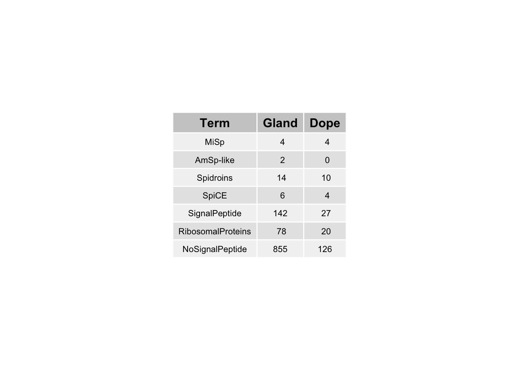

```r
table <- tableGrob(counts.protein,
                   rows = NULL,
                   theme = ttheme_default(core = list(fg_params = list(cex = 0.7))
                                          )
)
Figure2A <- ggplot() +
  annotation_custom(table) +
  theme_void()

Figure2A
```

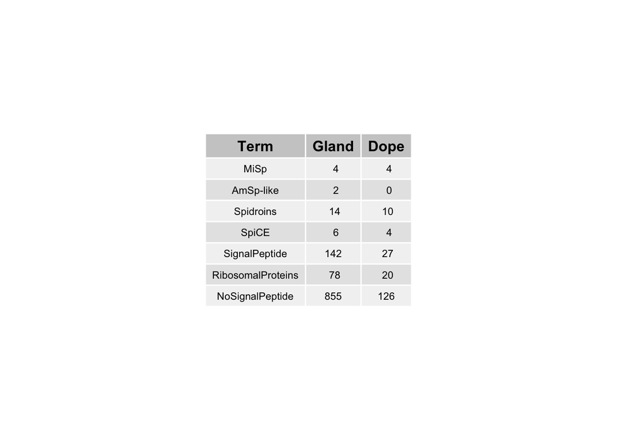

```r
ggsave(filename = here("MinorGland_paper", "figures_allSamples_block", "figure2", "figure2A.pdf"),
       plot = Figure2A,
       create.dir = TRUE,
       device = "pdf",
       width = 183 ,  # Convert mm to inches
       height = 120 ,  # Adjust height as needed
       units = "mm",
       dpi = 300  # High resolution for publication
       )

Figure2A
```

## Figure 2B

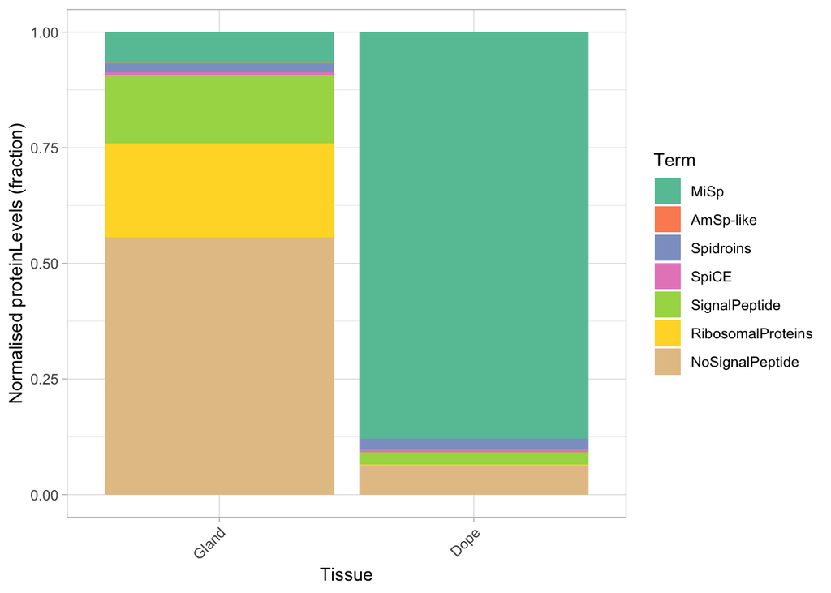

```r
minorProteomics.QC %>%
  inner_join(geneInfo)%>%
  group_by(Part,Term) %>%
  summarise(averageIntensity = sum(averageIntensity)) %>%
  mutate(Part = factor(Part, levels = c("Gland","Dope"))) %>%
  ggplot(aes(x = Part,y = averageIntensity,  fill = Term)) +
  geom_bar( stat = "identity", position = "fill" ) +
  theme_light() +
  theme(axis.text.x = element_text(angle = 45, hjust = 1)) +
  labs(
    x = "Tissue",
    y = "Normalised proteinLevels (fraction)"
  ) +
  scale_fill_brewer(palette = "Set2")  ->
  fig2B


ggsave(filename = here("MinorGland_paper", "figures_allSamples_block", "figure2", "figure2B.pdf"),
       plot = fig2B,
       create.dir = TRUE,
       device = "pdf",
       width = 183 ,  # Convert mm to inches
       height = 120 ,  # Adjust height as needed
       units = "mm",
       dpi = 300  # High resolution for publication
       )

fig2B
```

## Figure 2C

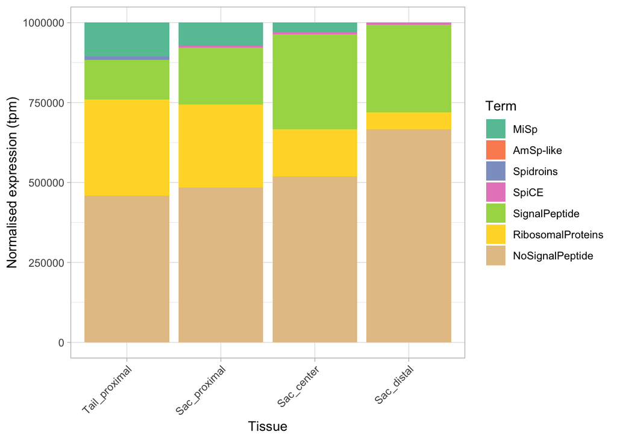

```r
# Showing the entire gland

#sampleInfo.QC.merged %>% filter(Tissue == "Minor") %>%
#  inner_join(bulk.data.merged.QC.tpm) %>%
#  group_by(gene_id) %>%
#  summarise(tpm = mean(tpm))%>%
#  mutate(Tissue = "Gland") %>%
#  inner_join(geneInfo) %>% group_by(Tissue,Term) %>%
#  summarise(tpmTot = sum(tpm))->
#  MinorGland.QC.tpm.long.summary

#MinorGland.QC.tpm.long.summary %>%
#  mutate(Tissue = factor(Tissue, levels = TissueOrder)) %>%
#  ggplot(aes(x = Tissue, y = tpmTot, fill = Term)) + geom_bar(stat = "identity") +
#  theme_light() + theme(axis.text.x = element_text(angle = 45, hjust = 1))




MinorCounts.QC.tpm.wide %>%
  pivot_longer(cols = -gene_id, names_to = "Tissue", values_to = "tpm")%>%
  inner_join(geneInfo) %>% group_by(Tissue,Term) %>%
  summarise(tpmTot = sum(tpm))->
  MinorParts.QC.tpm.long.summary

MinorParts.QC.tpm.long.summary %>%
  mutate(Tissue = factor(Tissue, levels = TissueOrder)) %>%
  ggplot(aes(x = Tissue, y = tpmTot, fill = Term)) +
  geom_bar(stat = "identity") +
  theme_light() +
  theme(axis.text.x = element_text(angle = 45, hjust = 1)) +
  labs(
    x = "Tissue",
    y = "Normalised expression (tpm)"
  ) +
  scale_fill_brewer(palette = "Set2") ->
  fig2C

ggsave(filename = here("MinorGland_paper", "figures_allSamples_block", "figure2", "figure2C.pdf"),
       plot = fig2C,
       create.dir = TRUE,
       device = "pdf",
       width = 183 ,  # Convert mm to inches
       height = 120 ,  # Adjust height as needed
       units = "mm",
       dpi = 300  # High resolution for publication
       )


fig2C
```

## Figure 2E

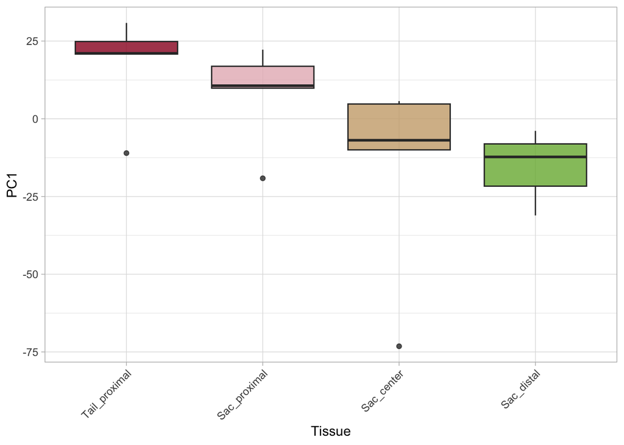

```r
# Save previous plot
ggsave(filename = here("MinorGland_paper", "figures_allSamples_block", "figure2", "figure2E.pdf"),
       plot = FigurePCA.minor.parts,
       width = 400,height = 800,units = "px")
FigurePCA.minor.parts
```

## Figure 2F

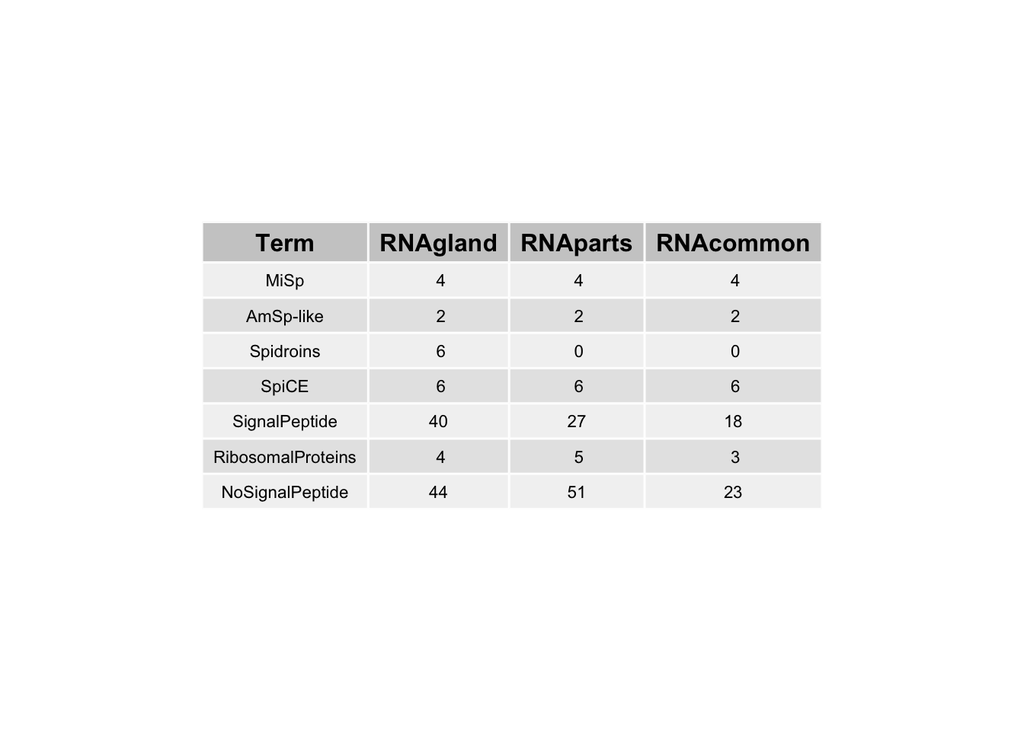

```r
counts %>% select(Term,RNAgland,RNAparts,RNAcommon) -> counts.protein

table <- tableGrob(counts.protein,
                   rows = NULL,
                   theme = ttheme_default(core = list(fg_params = list(cex = 0.7))
                                          )
)

Figure2F <- ggplot() +
  annotation_custom(table) +
  theme_void()

Figure2F
```

```r
ggsave(filename = here("MinorGland_paper", "figures_allSamples_block", "figure2", "figure2F.pdf"),
       plot = Figure2F,
       create.dir = TRUE,
       device = "pdf",
       width = 183 ,  # Convert mm to inches
       height = 120 ,  # Adjust height as needed
       units = "mm",
       dpi = 300  # High resolution for publication
)
```

## Figure 2G

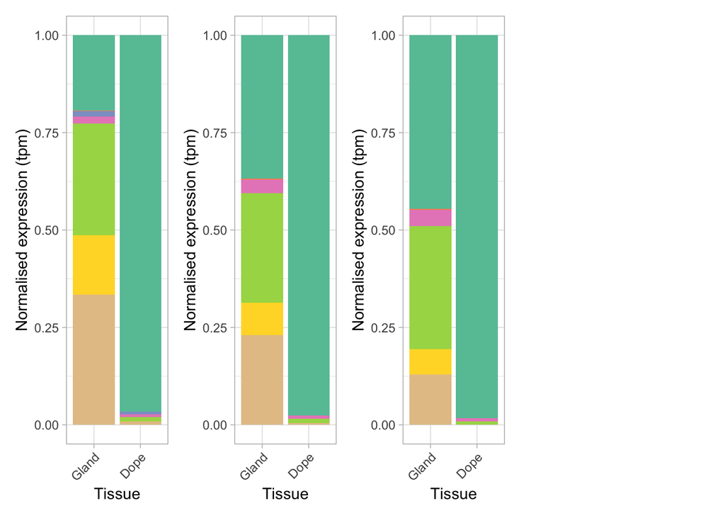

```r
minorProteomics.QC %>%
  inner_join(geneInfo)%>%
  inner_join(DEseq.gland.sig) %>%
  group_by(Part,Term) %>%
  summarise(averageIntensity = sum(averageIntensity)) %>%
  mutate(Part = factor(Part, levels = c("Gland","Dope"))) %>%
  ggplot(aes(x = Part,y = averageIntensity,  fill = Term)) +
  geom_bar( stat = "identity", position = "fill" ) +
  theme_light() +
  theme(axis.text.x = element_text(angle = 45, hjust = 1)) +
  labs(
    x = "Tissue",
    y = "Normalised expression (tpm)"
  ) +
  scale_fill_manual(values = termColors) ->
  fig2G.gland

minorProteomics.QC %>%
  inner_join(geneInfo)%>%
  inner_join(DEseq.part.sig) %>%
  group_by(Part,Term) %>%
  summarise(averageIntensity = sum(averageIntensity)) %>%
  mutate(Part = factor(Part, levels = c("Gland","Dope"))) %>%
  ggplot(aes(x = Part,y = averageIntensity,  fill = Term)) +
  geom_bar( stat = "identity", position = "fill" ) +
  theme_light() +
  theme(axis.text.x = element_text(angle = 45, hjust = 1)) +
  labs(
    x = "Tissue",
    y = "Normalised expression (tpm)"
  ) +
  scale_fill_manual(values = termColors) ->
  fig2G.part

minorProteomics.QC %>%
  inner_join(geneInfo)%>%
  inner_join(DEseq.common) %>%
  group_by(Part,Term) %>%
  summarise(averageIntensity = sum(averageIntensity)) %>%
  mutate(Part = factor(Part, levels = c("Gland","Dope"))) %>%
  ggplot(aes(x = Part,y = averageIntensity,  fill = Term)) +
  geom_bar( stat = "identity", position = "fill" ) +
  theme_light() +
  theme(axis.text.x = element_text(angle = 45, hjust = 1)) +
  labs(
    x = "Tissue",
    y = "Normalised expression (tpm)"
  ) +
  scale_fill_manual(values = termColors) ->
  fig2G.common



(fig2G.gland+ fig2G.part +fig2G.common )+
  plot_layout(guides = "collect", nrow = 1,widths = c(1,1,1,2)) &
  theme(legend.position = "none")  ->
  fig2G


fig2G
```

```r
ggsave(filename = here("MinorGland_paper", "figures_allSamples_block", "figure2", "figure2G.pdf"),
       plot = fig2G,
       create.dir = TRUE,
       device = "pdf",
       width = 183 ,  # Convert mm to inches
       height = 120 ,  # Adjust height as needed
       units = "mm",
       dpi = 300  # High resolution for publication
)
```

## Figure 2H

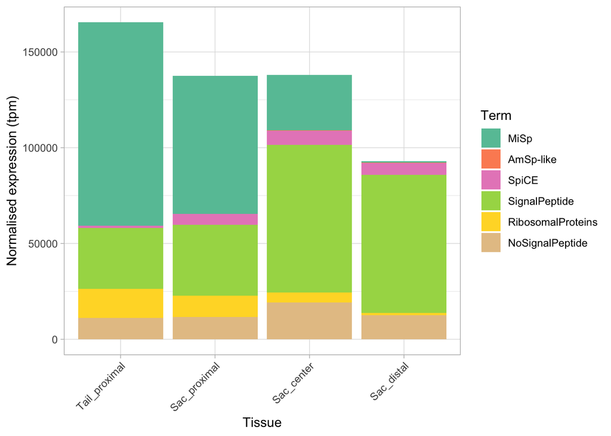

```r
MinorCounts.QC.tpm.wide %>%
  pivot_longer(cols = -gene_id, names_to = "Tissue", values_to = "tpm")%>%
  inner_join(geneInfo) %>%
  filter(geneNameProtein %in% DEseq.common$geneNameProtein  )%>%
  group_by(Tissue,Term) %>%
  summarise(tpm = sum(tpm))->
  MinorParts.QC.tpm.long.summary

MinorParts.QC.tpm.long.summary %>%
  mutate(Tissue = factor(Tissue, levels = TissueOrder)) %>%
  ggplot(aes(x = Tissue, y = tpm, fill = Term)) +
  geom_bar(stat = "identity") +
  theme_light() +
  theme(axis.text.x = element_text(angle = 45, hjust = 1)) +
  labs(
    x = "Tissue",
    y = "Normalised expression (tpm)"
  ) +
  scale_fill_manual(values = termColors) ->
  fig2H.together


fig2H.together
```

```r
ggsave(filename = here("MinorGland_paper", "figures_allSamples_block", "figure2", "figure2H.pdf"),
       plot = fig2H.together,
       create.dir = TRUE,
       device = "pdf",
       width = 183 ,  # Convert mm to inches
       height = 120 ,  # Adjust height as needed
       units = "mm",
       dpi = 300  # High resolution for publication
)
```

## Distribution of hits

```r
geneInfo %>%
  distinct(geneNameProtein, Term)%>%
  mutate(type = "Annotation") ->
  geneInfo.geneInfo

minorProteomics.expressed %>% inner_join(geneInfo) %>%
  distinct(geneNameProtein, Term)%>%
  mutate(type = "Protein") ->
  proteinPresent.geneInfo
DEseq.minor.head.results  %>%
  distinct(geneNameProtein, Term) %>%
  mutate(type = "DE_Tissue") ->
  DEseq.minor.head.pruned.geneInfo


DEseq.minor.parts.A.results.pruned %>%
  distinct(geneNameProtein, Term) %>%
  mutate(type = "DE_Part")  ->
  DEseq.minor.parts.A.results.pruned.geneInfo





inner_join(DEseq.minor.head.pruned.geneInfo[,c("geneNameProtein","Term")],
           DEseq.minor.parts.A.results.pruned.geneInfo[,c("geneNameProtein","Term")])  %>%
  mutate(type = "Both")  -> DEseq.minor.both.geneInfo
DEseq.minor.both.geneInfo %>%
  filter(Term != "NoSignalPeptide") %>%
  filter(Term != "RibosomalProteins") %>%
  mutate(type = "Final") ->
  DEseq.minor.final.geneInfo

bind_rows(geneInfo.geneInfo,proteinPresent.geneInfo,
          DEseq.minor.head.pruned.geneInfo,
          DEseq.minor.parts.A.results.pruned.geneInfo,
          DEseq.minor.both.geneInfo,
          DEseq.minor.final.geneInfo)  %>%
 mutate(type = factor(type, levels =c("Annotation","Protein","DE_Tissue","DE_Part", "Both","Final") )) ->
  all.geneInfo


all.geneInfo %>% group_by(Term, type) %>%
  summarise(n = n()) -> all.geneInfo.summary
```

```
## `summarise()` has regrouped the output.
## ℹ Summaries were computed grouped by Term and type.
## ℹ Output is grouped by Term.
## ℹ Use `summarise(.groups = "drop_last")` to silence this message.
## ℹ Use `summarise(.by = c(Term, type))` for per-operation grouping (`?dplyr::dplyr_by`) instead.
```

```r
all.geneInfo.summary %>% group_by(type) %>%
  summarise(total = sum(n))  %>% inner_join(all.geneInfo.summary ) %>%
  mutate(fraction = n /total) ->
  all.geneInfo.summary
```

```r
all.geneInfo.summary %>%
  ggplot(aes( x = type, y = fraction, fill = Term))+
  geom_bar(stat = "identity")+
  theme_light()+
  theme(axis.text.x = element_text(angle = 45, hjust = 1),
    legend.position = "none" ) +
  scale_fill_brewer(palette = "Set2")+
  labs(
    title = "Distribution of annotation",
    x = "Selection",
    y = "Fraction"
  ) ->
  distribution

all.geneInfo.summary %>%
  distinct(type,total) %>%
  ggplot(aes(x = type, y = total )) +
  geom_bar(stat = "identity") +
  geom_text(aes(label = total), hjust = 0.5, vjust = 2, size = 3, color = "white")+
  theme_light()+
  scale_y_log10() +
  theme(
    axis.title.x = element_blank(),
    axis.text.x = element_blank(),
    legend.position = "none"
  ) +
  labs(
    title = "Nr of genes",
    y = "log10(nrOfGenes)"
  )  -> count


count/distribution  -> fig2A


DEseq.minor.both.geneInfo %>% group_by(Term)%>%
  summarise(n = n())
```

| Term | n |
| --- | --- |
| MiSp | 4 |
| AmSp-like | 2 |
| SpiCE | 6 |
| SignalPeptide | 17 |
| RibosomalProteins | 1 |
| NoSignalPeptide | 20 |

```r
DEseq.minor.parts.A.results.pruned %>%
  distinct(geneNameProtein, baseMean)%>%
  filter(geneNameProtein %in% rownames(DEseq.parts.A.results.pruned.signalP.wide)) %>%
  select(geneNameProtein,baseMean) %>%
  column_to_rownames("geneNameProtein") ->
  baseMean.HM

DEseq.minor.parts.A.results.pruned %>%
  filter(geneNameProtein %in% rownames(DEseq.parts.A.results.pruned.signalP.wide)) %>%
  select(geneNameProtein,Tissue, log2FoldChange, padj,baseMean) %>%
  mutate(expLevel = baseMean*(2^log2FoldChange))  %>%     select(geneNameProtein,Tissue,expLevel,log2FoldChange,padj) %>%
  mutate(sigLevel = "None") %>%
  mutate(sigLevel = replace(sigLevel, padj < 0.1, "**")) %>%
  mutate(sigLevel = replace(sigLevel, padj < 0.05, "***")) %>%
  mutate(sigLevel = replace(sigLevel, padj < 0.0001, "****")) ->
    DEseq.parts.A.results.pruned.sig

 DEseq.minor.parts.A.results.pruned %>%
  distinct(geneNameProtein, baseMean)%>%
  filter(geneNameProtein %in% rownames(DEseq.parts.A.results.pruned.signalP.wide)) %>%
  select(geneNameProtein,baseMean) %>%
   rename(expLevel = "baseMean" ) %>%
   mutate(Tissue = "Tail_proximal") %>%
   mutate(log2FoldChange = 0) %>%
   mutate(padj = 1) %>%
   mutate(sigLevel = "None") ->
     DEseq.parts.Tail_proximal


 bind_rows(DEseq.parts.A.results.pruned.sig,DEseq.parts.Tail_proximal) %>%
   arrange(geneNameProtein) ->DEseq.parts.A.results.pruned.sig


 # A contrast where DESeq2 returns padj = NA (e.g. count outlier) has no row in the
 # results tables. Add those cells back with the raw log2FC and no significance so every
 # gene has a value in every part.
 bind_rows(
  as.data.frame(resSpAp) %>% rownames_to_column("gene_id") %>% mutate(Tissue = "Sac_proximal"),
  as.data.frame(resScTp) %>% rownames_to_column("gene_id") %>% mutate(Tissue = "Sac_center"),
  as.data.frame(resSdTp) %>% rownames_to_column("gene_id") %>% mutate(Tissue = "Sac_distal")) %>%
  inner_join(geneInfo %>% select(gene_id, geneNameProtein), by = "gene_id") %>%
  select(geneNameProtein, Tissue, log2FC.raw = log2FoldChange) ->
  log2FC.raw

 DEseq.parts.A.results.pruned.sig %>%
  complete(geneNameProtein,
           Tissue = c("Sac_proximal","Sac_center","Sac_distal","Tail_proximal")) %>%
  left_join(log2FC.raw, by = c("geneNameProtein", "Tissue")) %>%
  left_join(baseMean.HM %>% rownames_to_column("geneNameProtein"), by = "geneNameProtein") %>%
  mutate(log2FoldChange = coalesce(log2FoldChange, log2FC.raw),
         expLevel = coalesce(expLevel, baseMean * 2^log2FoldChange),
         sigLevel = replace_na(sigLevel, "None")) %>%
  select(-log2FC.raw, -baseMean) ->
  DEseq.parts.A.results.pruned.sig

 DEseq.parts.A.results.pruned.sig %>%
  mutate(log10expLevel = log10(expLevel)) ->
  DEseq.parts.A.results.pruned.sig.2


 DEseq.parts.A.results.pruned.sig.2 %>% distinct(geneNameProtein)
```

| geneNameProtein |
| --- |
| acp7 |
| AmSp-like1 |
| AmSp-like2 |
| cd109 |
| cg3556_2 |
| grn_6 |
| hsp90b1 |
| hspa5_2 |
| LASC000038 |
| LASC001730 |

[output cut: 29 more lines]

```r
library(cluster)
library(factoextra)
DEseq.parts.A.results.pruned.sig.2 %>%
  select(geneNameProtein,Tissue,log2FoldChange) %>%
  pivot_wider(names_from = "Tissue", values_from = "log2FoldChange") %>%
  column_to_rownames("geneNameProtein") %>%
  as.matrix() -> mat

m <- c( "average", "single", "complete", "ward")
names(m) <- c( "average", "single", "complete", "ward")

df = mat
ac <- function(x) {
  agnes(df, method = x)$ac
}
sapply(m, ac)
```

```
##   average    single  complete      ward
## 0.9106505 0.7612816 0.9447386 0.9765253
```

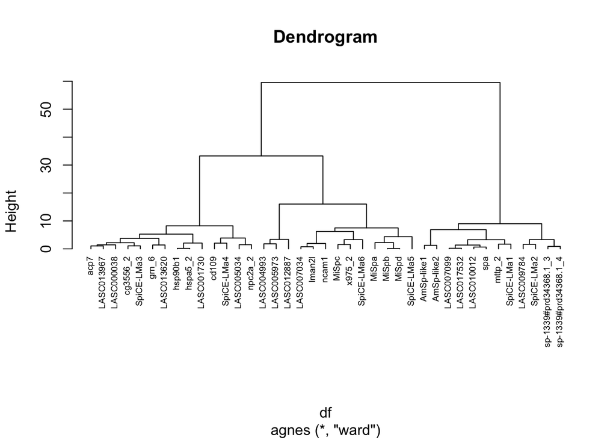

```r
clust <- agnes(df, method = "ward")
pltree(clust, cex = 0.6, hang = -1, main = "Dendrogram")
```

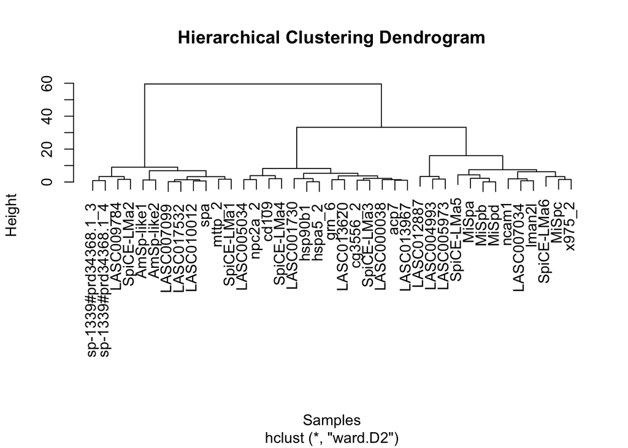

```r
gap_stat <- clusGap(df, FUN = hcut, nstart = 25, K.max = 6, B = 50 )
#produce plot of clusters vs. gap statistic

gap_stat_plot <- fviz_gap_stat(gap_stat) +
  ggtitle("Gap Statistic Plot") +
  xlab("Number of Clusters") +
  ylab("Gap Statistic") +
  theme_minimal()

d <- dist(df, method = "euclidean")

#perform hierarchical clustering using Ward's method
final_clust <- hclust(d, method = "ward.D2" )
#cut the dendrogram into 3 clusters
plot(final_clust, main = "Hierarchical Clustering Dendrogram", xlab = "Samples", ylab = "Height")
```

```r
# Cluster numbers depend on the data, so name the clusters by their mean log2FC in
# Sac_center and Sac_distal: strongest = sac_bulk_1, next = sac_bulk_2, lowest = tail_bulk_1
clust.k3 <- cutree(final_clust, 3)
clust.score <- tapply(rowMeans(mat[names(clust.k3), c("Sac_center","Sac_distal")]), clust.k3, mean)
clust.name <- setNames(c("sac_bulk_1","sac_bulk_2","tail_bulk_1"),
                       names(sort(clust.score, decreasing = TRUE)))

genes = data.frame(geneName = names(clust.k3) ,
                   hierarchicalCluster = paste("c",clust.k3,sep ="_")) %>%
  mutate(hierarchicalCluster2 = clust.name[as.character(clust.k3)]) %>%
  arrange(hierarchicalCluster2)
```

# Figure 3

Keeping only the genes that are in the DEseq parts A results and have a signal peptide

```r
DEseq.parts.A.results.pruned.sig.2 %>%
  filter(geneNameProtein %in% DEseq.common.27$geneNameProtein ) ->
  DEseq.parts.A.results.pruned.sig.2
```

## RNA expression

```r
library(circlize)
```

```r
library(ComplexHeatmap)
# Sample Data
DEseq.parts.A.results.pruned.sig.2 %>%
  filter(Tissue != "Tail_proximal") %>%
  select(geneNameProtein,Tissue,log2FoldChange) %>%
  pivot_wider(names_from = "Tissue", values_from = "log2FoldChange") %>%
  column_to_rownames("geneNameProtein") %>%
  as.matrix() -> mat_DEseq

MinorCounts.QC.tpm %>% inner_join(MinorSampleInfo.QC.MiAG)  %>%
  select(geneNameProtein,Tissue,sample,tpm) %>%
  filter(geneNameProtein %in% rownames(mat_DEseq)) %>%
  group_by(geneNameProtein,Tissue) %>%
  summarise(tpm = mean(tpm)) %>%
  mutate(log10tpm = log10(tpm)) %>%
  select(-tpm) %>%
  pivot_wider(names_from = "Tissue" , values_from = "log10tpm") %>%
  column_to_rownames("geneNameProtein") %>%
   as.matrix()->
  mat_DEseq_exp
```

```
## `summarise()` has regrouped the output.
## ℹ Summaries were computed grouped by geneNameProtein and Tissue.
## ℹ Output is grouped by geneNameProtein.
## ℹ Use `summarise(.groups = "drop_last")` to silence this message.
## ℹ Use `summarise(.by = c(geneNameProtein, Tissue))` for per-operation grouping (`?dplyr::dplyr_by`) instead.
```

## Figure 3A

```r
#install.packages("ggVennDiagram")

three_set_venn <- ggVennDiagram(genesOfInterest)

pdf(here("MinorGland_paper", "figures_allSamples_block", "Figure3", "figure3A.pdf"),
    width = 2, height = 4)
print(three_set_venn)
dev.off()
```

## Figure 3B

```r
clusters <- cutree(final_clust, k = 3)

# Name clusters by strength in the sac (the cluster numbering depends on the data)
clusters.score <- tapply(rowMeans(mat[names(clusters), c("Sac_center","Sac_distal")]), clusters, mean)
clusters.names <- setNames(c("Sac strong","Sac weak","Tail strong"),
                           names(sort(clusters.score, decreasing = TRUE)))

data.frame(clusters) %>%
  rownames_to_column(var = "geneNameProtein") %>%
  inner_join(DEseq.parts.A.results.pruned.sig.2) %>%
  mutate(Tissue = factor(Tissue, level = TissueOrder)) %>%
  mutate(cluster2 = clusters.names[as.character(clusters)]) ->
  minor.bulk.final.cluster.data
```

```r
minor.bulk.final.cluster.data%>%
  ggplot( aes(y = log2FoldChange, fill = as.factor(cluster2), x = Tissue)) + geom_boxplot()+
  theme_light()+ theme(axis.text.x = element_text(angle = 45, hjust = 1)) +
  scale_fill_manual(values = BulkZones) -> Fig3B


ggsave(filename = here("MinorGland_paper", "figures_allSamples_block", "Figure3", "figure3B.pdf"),
       plot = Fig3B,
       create.dir = TRUE,
       device = "pdf",
       width = 240 ,  # Convert mm to inches
       height = 120 ,  # Adjust height as needed
       units = "mm",
       dpi = 300  # High resolution for publication
)
```

## Figure 3C

### Figure 3C Parts

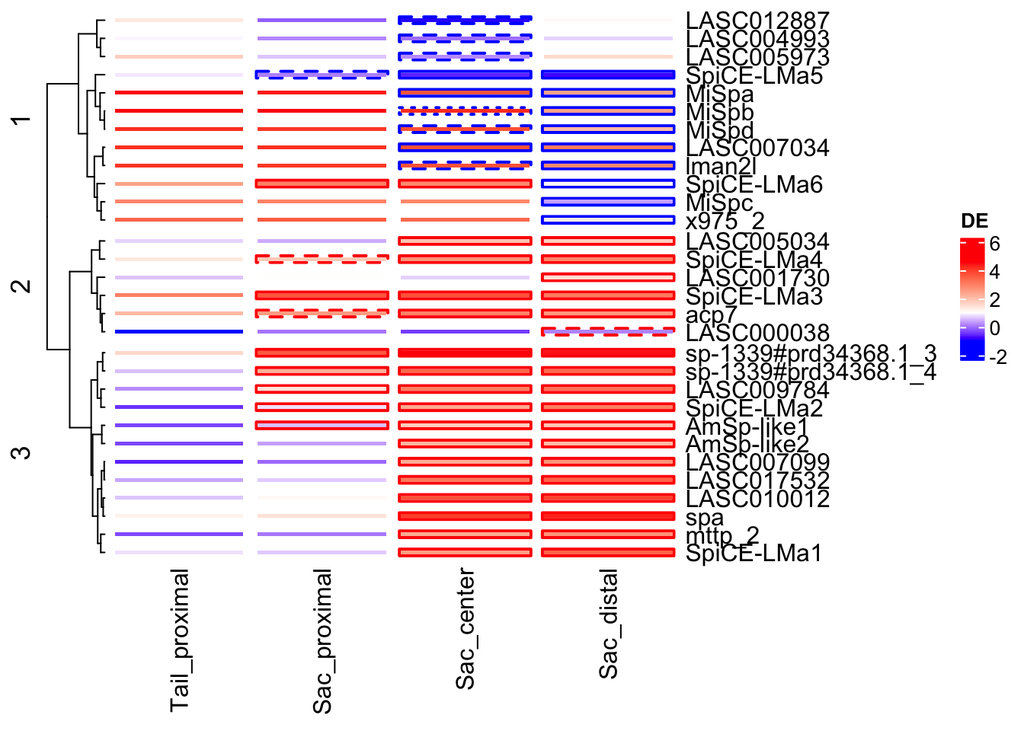

```r
DEseq.parts.A.results.pruned.sig.2 %>%
  select(geneNameProtein,Tissue,sigLevel) %>%
  pivot_wider(names_from = "Tissue", values_from = "sigLevel") %>%
  column_to_rownames("geneNameProtein") %>%
  as.matrix() -> border_data

DEseq.parts.A.results.pruned.sig.2 %>%
  mutate(diff = "Up") %>%
  mutate(diff  = replace(diff, log2FoldChange <0,"Down")) %>%
  select(geneNameProtein,Tissue,diff) %>%
  pivot_wider(names_from = "Tissue", values_from = "diff") %>%
  column_to_rownames("geneNameProtein") %>%
  as.matrix() -> border_color



# Color palettes
min_val <- min(mat_DEseq_exp)
max_val <- max(mat_DEseq_exp)
col_fun <- colorRamp2(c(min_val, 1 ,max_val), c("blue", "white", "red")) # Corrected color mapping
border_colors <- c("Up" = "red", "Down" = "blue","None"="black")
border_styles <- c("None" = "blank","**" = "dotted", "***" = "dashed", "****" = "solid")

# Create the heatmap with cell gap


distance_matrix <- dist(mat_DEseq)

# Perform hierarchical clustering
hc <- hclust(distance_matrix)

# Convert hclust to a dendrogram
row_dend <- as.dendrogram(hc)


clusters <- cutree(hc, k = 3)



# Create the heatmap
mat_DEseq_exp = mat_DEseq_exp[rownames(mat_DEseq),
                              c("Tail_proximal","Sac_proximal","Sac_center","Sac_distal")]
border_data = border_data[rownames(mat_DEseq),
                          c("Tail_proximal","Sac_proximal","Sac_center","Sac_distal")]
border_color = border_color[rownames(mat_DEseq),
                          c("Tail_proximal","Sac_proximal","Sac_center","Sac_distal")]
Heatmap(mat_DEseq_exp,
        col = col_fun,
        cluster_rows = row_dend, # Add the row dendrogram
        rect_gp = gpar(type = "none"), #Important to remove the default drawing of the cells
        cell_fun = function(j, i, x, y, width, height, fill) {
          border_lty <- border_styles[border_data[i, j]]
          border_col <- border_colors[border_color[i, j]]
          grid.rect(x = x, y = y, width = width - unit(2, "mm"), height = height - unit(2, "mm"),
                    gp = gpar(col = border_col, lty = border_lty, lwd = 2), just = "center")
          grid.rect(x = x, y = y, width = width - unit(2.5, "mm"), height = height - unit(2.5, "mm"), # Cell gap
                              gp = gpar(fill = col_fun(mat_DEseq_exp[i,j]), col = NA), just = "center") # Remove black outline
 #Fill the cells with the color gradient
        },
        row_names_side = "right",
        column_names_side = "bottom",
        name = "DE",
        row_gap = unit(0.5, "mm"),
        column_gap = unit(0.5,"mm"),
      cluster_columns = FALSE,split = 3) ->
  HM1

HM1
```

```r
ordered_genes <- rownames(mat_DEseq)[hc$order]
ordered_genes
```

```
##  [1] "LASC012887"           "LASC004993"           "LASC005973"
##  [4] "SpiCE-LMa5"           "MiSpa"                "MiSpb"
##  [7] "MiSpd"                "LASC007034"           "lman2l"
## [10] "SpiCE-LMa6"           "MiSpc"                "x975_2"
## [13] "LASC005034"           "SpiCE-LMa4"           "LASC001730"
## [16] "SpiCE-LMa3"           "acp7"                 "LASC000038"
## [19] "sp-1339#prd34368.1_3" "sp-1339#prd34368.1_4" "LASC009784"
## [22] "SpiCE-LMa2"           "AmSp-like1"           "AmSp-like2"
## [25] "LASC007099"           "LASC017532"           "LASC010012"
## [28] "spa"                  "mttp_2"               "SpiCE-LMa1"
```

### Figure 3C Whole tissues

```r
bulk.data.merged.QC.tpm %>%
  inner_join(geneInfo) %>%
  filter(geneNameProtein %in% rownames(mat_DEseq)) %>%
  inner_join(sampleInfo.QC.merged)%>%
  filter(Tissue %in% c("Minor","Major","Head")) %>%
  group_by(geneNameProtein,Tissue) %>%
  summarise(mean = mean(tpm))  %>%
  pivot_wider(names_from = "Tissue", values_from = "mean") %>%
  column_to_rownames("geneNameProtein") %>%
  select(Head,Major,Minor) %>%
  as.matrix() -> mat_tissue
```

```
## `summarise()` has regrouped the output.
```

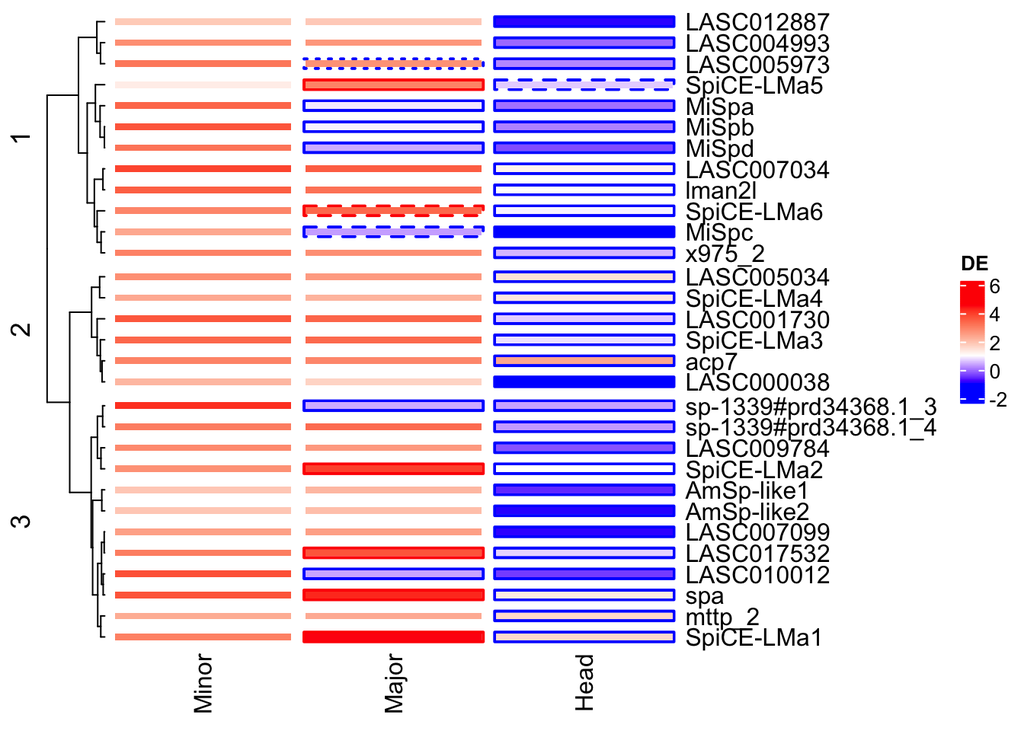

```r
mat_tissue = log10(mat_tissue)
mat_tissue = mat_tissue[rownames(mat_DEseq),c("Minor","Major","Head")]
border_colors <- c("Up" = "blue", "Down" = "red","None"="black")


DEseq.minor.gland.HM.results %>%
  select(geneNameProtein,Tissue,sigLevel) %>%
  pivot_wider(names_from = "Tissue", values_from = "sigLevel") %>%
  column_to_rownames("geneNameProtein") %>%
  mutate(Minor = "None") %>%
  as.matrix() -> border_data

border_data = border_data[rownames(mat_DEseq),c("Minor","Major","Head")]


DEseq.minor.gland.HM.results %>%
  select(geneNameProtein,Tissue,dir) %>%
  pivot_wider(names_from = "Tissue", values_from = "dir") %>%
  column_to_rownames("geneNameProtein") %>%
    mutate(Minor = "None") %>%
  as.matrix() -> border_dir
border_dir = border_dir[rownames(mat_DEseq),c("Minor","Major","Head")]



# Create the heatmap


Heatmap(mat_tissue,
        col = col_fun,
        cluster_rows = row_dend, # Add the row dendrogram
        rect_gp = gpar(type = "none"), #Important to remove the default drawing of the cells
        cell_fun = function(j, i, x, y, width, height, fill) {
          border_lty <- border_styles[border_data[i, j]]
          border_col <- border_colors[border_dir[i, j]]
          grid.rect(x = x, y = y, width = width - unit(2, "mm"), height = height - unit(2, "mm"),
                    gp = gpar(col = border_col, lty = border_lty, lwd = 2), just = "center")
          grid.rect(x = x, y = y, width = width - unit(2.5, "mm"), height = height - unit(2.5, "mm"), # Cell gap
                              gp = gpar(fill = col_fun(mat_tissue[i,j]), col = NA), just = "center") # Remove black outline
 #Fill the cells with the color gradient
        },
        row_names_side = "right",
        column_names_side = "bottom",
        name = "DE",
        row_gap = unit(0.5, "mm"),
        column_gap = unit(0.5,"mm"),
      cluster_columns = FALSE,split = 3) ->
  HM1_tissue

HM1_tissue
```

```r
row_dend$labels = ordered_genes
```

### Figure 3C Protein expression

```r
minorProteomics.QC %>%
  inner_join(geneInfo) %>%
  filter(geneNameProtein %in% rownames(mat_DEseq)) %>%
  select(geneNameProtein,Part,averageIntensity) %>%
  pivot_wider(names_from = "Part", values_from = "averageIntensity")  ->
  minorProteomics.wide
```

```r
minorProteomics.wide  %>%
  filter(geneNameProtein %in% rownames(mat_DEseq)) %>%
  select(geneNameProtein,Gland,Dope) %>%
  column_to_rownames("geneNameProtein") ->
  prot.express.HM

prot.express.HM = prot.express.HM[rownames(mat_DEseq),]

prot.express.HM = log10(prot.express.HM)
# Color palettes
col_fun_Protein <- colorRamp2(c(min(prot.express.HM, na.rm = TRUE),
                        -3 ,
                        max(prot.express.HM, na.rm = TRUE)),
                      c("blue", "white", "red")) # Corrected color mapping
border_colors <- c("None" = "lightgrey", "***" = "darkgrey", "****" = "black")
border_styles <- c("None" = "blank","**" = "dotted", "***" = "dashed", "****" = "solid")



# Create the heatmap


prot.express.HM = prot.express.HM[rownames(mat_DEseq),]

Heatmap(prot.express.HM,
        col = col_fun_Protein,
        na_col = NA,
        rect_gp = gpar(type = "none"), #Important to remove the default drawing of the cells
        cell_fun = function(j, i, x, y, width, height, fill) {
          if (!is.na(prot.express.HM[i, j])) {
            grid.rect(x = x, y = y, width = width - unit(2, "mm"), height = height - unit(2, "mm"),
                    gp = gpar(col = "black",  lwd = 2), just = "center")
          }
          grid.rect(x = x, y = y, width = width - unit(2.5, "mm"), height = height - unit(2.5, "mm"), # Cell gap
                              gp = gpar(fill = col_fun_Protein(prot.express.HM[i,j]), col = NA), just = "center") # Remove black outline
 #Fill the cells with the color gradient
        },
        row_names_side = "right",
        column_names_side = "bottom",
        name = "Protein expression",
        row_gap = unit(0.5, "mm"),
        column_gap = unit(0.5,"mm"),
        cluster_columns = FALSE) ->
  HM2
```

### Figure 3C Combined heatmap

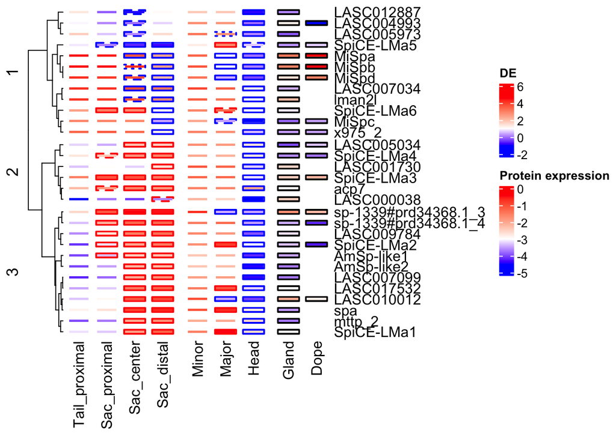

```r
HM1+HM1_tissue+HM2 -> HM_all
HM_all
```

```r
library(ComplexHeatmap)
library(grid)

# Draw heatmap in rotated grid


pdf(here("MinorGland_paper", "figures_allSamples_block", "Figure3", "figure3C.pdf"),
    width = 10, height = 10)
HM_all
dev.off()
```

# Compare protein and RNA levels

## Supplementary figure 6

```r
minorProteomics.QC %>%
  inner_join(geneInfo) %>%
  select(geneNameProtein,Part,averageIntensity) %>%
  pivot_wider(names_from = "Part", values_from = "averageIntensity")  ->
  minorProteomics.wide.all
bulk.data.merged.QC.tpm %>% inner_join(sampleInfo.QC.merged.DE) %>%
  filter(Tissue == "Minor" & part == "Gland") %>%
  group_by(gene_id) %>%
  summarise(tpm = mean(tpm)) %>% inner_join(geneInfo) %>%
 left_join(minorProteomics.wide.all) %>%
   mutate(Term = factor(Term, levels = c("MiSp","AmSp-like","Spidroins","SpiCE","SignalPeptide","RibosomalProteins","NoSignalPeptide")) ) ->
  minor.RNA.protein
```

```r
minor.RNA.protein %>%
  mutate(proteinDetected = "No") %>%
  mutate(proteinDetected = replace(proteinDetected, !is.na(Gland),"Yes")) ->
  minor.RNA.protein

minor.RNA.protein %>%
  filter(tpm > 0) %>%
  ggplot(aes(x = log2(tpm+1) , color = proteinDetected)) +
  geom_vline(xintercept = 2, color = "black")+
  geom_density()+
   scale_color_brewer(palette = "Set1")  +
  theme_light() +
  labs(
    x = "log2(tpm+1)",
    y = "Density",
    title = "Distribution of RNA expression in the Minor gland and protein detection status"
  ) ->
  ProteinRNAexpression.minor.1

minor.RNA.protein %>%
  filter(geneNameProtein %in% rownames(mat_DEseq)) ->
  selected

minor.RNA.protein %>%
  filter(tpm>2^2) %>%
  filter(Gland >0.00009) ->
  background





minor.RNA.protein %>%
  filter(!is.na(Gland)) %>%
  filter(tpm > 3)->
  test
cor.test(x = log10(test$tpm), y = log10(test$Gland))
```

```
##
##  Pearson's product-moment correlation
##
## data:  log10(test$tpm) and log10(test$Gland)
## t = 24.339, df = 1029, p-value < 2.2e-16
## alternative hypothesis: true correlation is not equal to 0
## 95 percent confidence interval:
##  0.5642237 0.6418227
## sample estimates:
##       cor
## 0.6044551
```

```r
DEseq.minor.gland.HM.results %>% filter(dir == "Up" ) %>% filter(sigLevel %in% c("***","****")) %>% filter(Tissue == "Major") -> upMinor

selected %>% filter(geneNameProtein %in% upMinor$geneNameProtein) ->selected.up

selected %>%
  ggplot(aes(x = log2(tpm+1), y = log2(Gland*100), color = Term, label = geneNameProtein)) +
  geom_point(data = background, alpha = 0.7, size = 0.6)+
  geom_point(alpha = 1, size = 3)+
  geom_smooth(data =background, color = "black", method = "lm")+
  geom_text_repel(data =selected.up, aes(label = geneNameProtein) , color = "black" )+
    labs(
    x = "log2(tpm+1)",
    y = "Percent of Intensity",
    title = "RNA and protein levels in the Minor gland\n of genes with identified protein expression"
  )+
  scale_color_brewer(palette = "Set2") +
  theme_light()+
  xlim(0,18)->
  ProteinRNAexpression.minor.2



ProteinRNAexpression.minor.1 + ProteinRNAexpression.minor.2 + plot_layout(ncol = 1) -> RNAprotein.disitribution


ggsave(filename = here("MinorGland_paper", "figures_allSamples_block",
                       "supplementaryFigures", "SupplFig6","SupplFig6.pdf"),
       plot = RNAprotein.disitribution,
       create.dir = TRUE,
       device = "pdf",
       width = 183 ,  # Convert mm to inches
       height = 200 ,  # Adjust height as needed
       units = "mm",
       dpi = 300  # High resolution for publication
)
cor.test(log2(background$tpm),log2(background$Gland))
```

```
##
##  Pearson's product-moment correlation
##
## data:  log2(background$tpm) and log2(background$Gland)
## t = 25.439, df = 1011, p-value < 2.2e-16
## alternative hypothesis: true correlation is not equal to 0
## 95 percent confidence interval:
##  0.5856730 0.6608934
## sample estimates:
##       cor
## 0.6247304
```

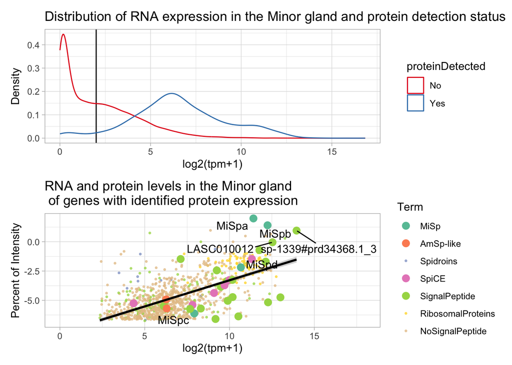

```r
RNAprotein.disitribution
```